# ANOVA test for coerencia_tematica

Geiser C. Challco geiser@alumni.usp.br

- ANOVA: coerencia_tematica ~ time
  - Data Preparation
  - Summary Statistics
  - ANOVA Computation
  - PairWise Computation
- ANOVA: coerencia_tematica ~ time*gender + Error(id/time)
  - Data Preparation
    - Check assumptions: Identifying Outliers
    - Check assumptions: Normality Test
    - Summary Statistics
  - ANOVA Computation
  - ANOVA Computation after removing non.normal data
  - PairWise Computation
  - PairWise Computation after removing non.normal data
- ANOVA: coerencia_tematica ~ time*localizacao + Error(id/time)
  - Data Preparation
    - Check assumptions: Identifying Outliers
    - Check assumptions: Normality Test
    - Summary Statistics
  - ANOVA Computation
  - ANOVA Computation after removing non.normal data
  - PairWise Computation
  - PairWise Computation after removing non.normal data
- ANOVA: coerencia_tematica ~ time*regiao + Error(id/time)
  - Data Preparation
    - Check assumptions: Identifying Outliers
    - Check assumptions: Normality Test
    - Summary Statistics
  - ANOVA Computation
  - ANOVA Computation after removing non.normal data
  - PairWise Computation
  - PairWise Computation after removing non.normal data
- ANOVA: coerencia_tematica ~ time*porte + Error(id/time)
  - Data Preparation
    - Check assumptions: Identifying Outliers
    - Check assumptions: Normality Test
    - Summary Statistics
  - ANOVA Computation
  - ANOVA Computation after removing non.normal data
  - PairWise Computation
  - PairWise Computation after removing non.normal data

```r
dat <- read_excel("../data/data.xlsx", sheet = "alunos_ef59")

escolas <- read_excel("../data/data.xlsx", sheet = "escolas")
edat <- merge(dat, escolas, by = "cod_escola", all.x = T)
```

# ANOVA: coerencia_tematica ~ time

## Data Preparation

```r
data <- edat[,c("aluno_id","ciclo","coerencia_tematica")]
data <- data[data$ciclo %in% c("Segundo Ciclo","Terceiro Ciclo"),]
data$ciclo <- factor(data$ciclo, c("Segundo Ciclo","Terceiro Ciclo"))
data <- unique(data)

wdat <- spread(data, ciclo, coerencia_tematica)
wdat <- wdat[complete.cases(wdat),]
colnames(wdat) <- c("id","c2","c3")

ldat <- gather(wdat, key = time, value = coerencia_tematica, c2,c3) %>%
  convert_as_factor(id, time)
ldat <- rshinystatistics::remove_group_data(ldat, "coerencia_tematica", "time", n.limit = 30)
```

## Summary Statistics

```r
(sdat <- ldat %>% group_by(time) %>%
   get_summary_stats(coerencia_tematica, type = "mean_sd"))
```

```
## # A tibble: 2 × 5
##   time  variable               n  mean    sd
##   <fct> <fct>              <dbl> <dbl> <dbl>
## 1 c2    coerencia_tematica  4042  1.03 0.173
## 2 c3    coerencia_tematica  4042  1.03 0.17
```

| time | variable | n | mean | sd |
| --- | --- | --- | --- | --- |
| c2 | coerencia_tematica | 4042 | 1.030 | 0.173 |
| c3 | coerencia_tematica | 4042 | 1.027 | 0.170 |

## ANOVA Computation

```r
(res.aov <- anova_test(ldat, dv = coerencia_tematica, wid = id, within = time))
```

```
## ANOVA Table (type III tests)
##
##   Effect DFn  DFd     F     p p<.05      ges
## 1   time   1 4041 0.592 0.442       6.39e-05
```

## PairWise Computation

```r
(pwc <- ldat %>% emmeans_test(coerencia_tematica ~ time, detailed = T, p.adjust.method = "bonferroni"))
```

```
## # A tibble: 1 × 14
##   term  .y.   group1 group2 null.value estimate      se    df conf.low conf.high
## * <chr> <chr> <chr>  <chr>       <dbl>    <dbl>   <dbl> <dbl>    <dbl>     <dbl>
## 1 time  coer… c2     c3              0  0.00275 0.00383  8082 -0.00475    0.0103
## # ℹ 4 more variables: statistic <dbl>, p <dbl>, p.adj <dbl>, p.adj.signif <chr>
```

| term | .y. | group1 | group2 | null.value | estimate | se | df | conf.low | conf.high | statistic | p | p.adj | p.adj.signif |
| --- | --- | --- | --- | --- | --- | --- | --- | --- | --- | --- | --- | --- | --- |
| time | coerencia_tematica | c2 | c3 | 0 | 0.003 | 0.004 | 8082 | -0.005 | 0.01 | 0.719 | 0.472 | 0.472 | ns |

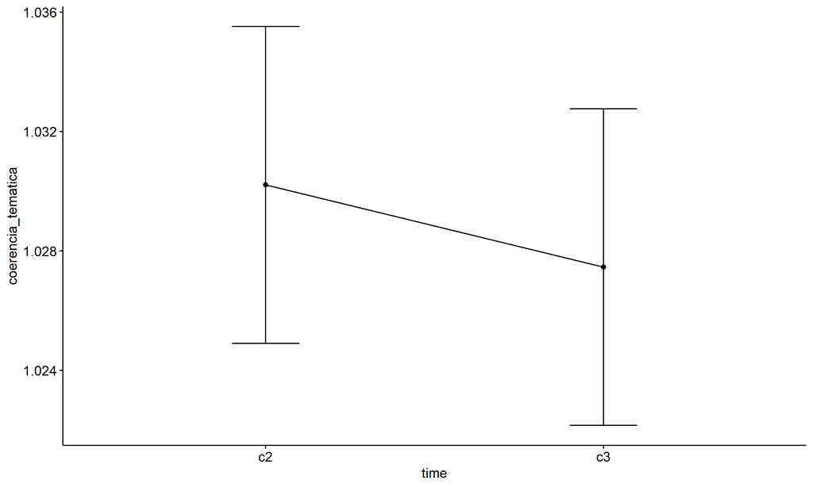

```r
pwc <- add_xy_position(pwc, x = "time", fun = "mean_se")
ggline(get_emmeans(pwc), x = "time", y = "emmean", ylab = "coerencia_tematica") +
  geom_errorbar(aes(ymin = conf.low, ymax = conf.high), width = 0.2) +
  stat_pvalue_manual(pwc, hide.ns = T, tip.length = F)
```

# ANOVA: coerencia_tematica ~ time*gender + Error(id/time)

## Data Preparation

```r
data <- edat[,c("aluno_id","gender","ciclo","coerencia_tematica")]
data <- data[data$ciclo %in% c("Segundo Ciclo","Terceiro Ciclo"),]
data$ciclo <- factor(data$ciclo, c("Segundo Ciclo","Terceiro Ciclo"))
data <- unique(data)

wdat <- spread(data, ciclo, coerencia_tematica)
wdat <- wdat[complete.cases(wdat),]
colnames(wdat) <- c("id","gender","c2","c3")

ldat <- gather(wdat, key = time, value = coerencia_tematica, c2,c3) %>%
  convert_as_factor(id, time)
ldat <- remove_group_data(ldat, "coerencia_tematica", c("time", "gender"), n.limit = 30)
ldat$gender <- factor(ldat$gender, sort(unique(ldat$gender)))
```

### Check assumptions: Identifying Outliers

```r
outliers <- identify_outliers(group_by(ldat, time, gender), coerencia_tematica)
(outliers <- outliers[outliers$is.extreme == T,])
```

```
## # A tibble: 236 × 6
##    gender time  id                   coerencia_tematica is.outlier is.extreme
##    <fct>  <fct> <fct>                             <dbl> <lgl>      <lgl>
##  1 Female c2    a8SWsJUcxVnZgfDuYhl9                1.5 TRUE       TRUE
##  2 Female c2    aGe8oY0BM2o4WY2b3cMO                1.5 TRUE       TRUE
##  3 Female c2    aHRArOnxnMCJAnjRvMkz                1.5 TRUE       TRUE
##  4 Female c2    bBBGsbvYBLgWujzEuOES                2   TRUE       TRUE
##  5 Female c2    bEH3ieH27FIqcQO2qaG5                1.5 TRUE       TRUE
##  6 Female c2    cFxwLMwyCxWzWrkpwvkt                3   TRUE       TRUE
##  7 Female c2    cUepYSggkyNVXrET7RCr                2   TRUE       TRUE
##  8 Female c2    dzxWSwAxb1LbKLWq0f8W                2   TRUE       TRUE
##  9 Female c2    e4T8ur8rXZ7jH6myH0wq                2   TRUE       TRUE
## 10 Female c2    eakSXIhde0LSciiZKTJf                1.5 TRUE       TRUE
## # ℹ 226 more rows
```

| gender | time | id | coerencia_tematica | is.outlier | is.extreme |
| --- | --- | --- | --- | --- | --- |
| Female | c2 | a8SWsJUcxVnZgfDuYhl9 | 1.500 | TRUE | TRUE |
| Female | c2 | aGe8oY0BM2o4WY2b3cMO | 1.500 | TRUE | TRUE |
| Female | c2 | aHRArOnxnMCJAnjRvMkz | 1.500 | TRUE | TRUE |
| Female | c2 | bBBGsbvYBLgWujzEuOES | 2.000 | TRUE | TRUE |
| Female | c2 | bEH3ieH27FIqcQO2qaG5 | 1.500 | TRUE | TRUE |
| Female | c2 | cFxwLMwyCxWzWrkpwvkt | 3.000 | TRUE | TRUE |
| Female | c2 | cUepYSggkyNVXrET7RCr | 2.000 | TRUE | TRUE |
| Female | c2 | dzxWSwAxb1LbKLWq0f8W | 2.000 | TRUE | TRUE |
| Female | c2 | e4T8ur8rXZ7jH6myH0wq | 2.000 | TRUE | TRUE |
| Female | c2 | eakSXIhde0LSciiZKTJf | 1.500 | TRUE | TRUE |
| Female | c2 | eMaYeLRiclZymf00Bgj3 | 2.000 | TRUE | TRUE |
| Female | c2 | fZbZWnu3vvhrwYpmrO9k | 2.000 | TRUE | TRUE |
| Female | c2 | g1Y9akoQG5mxUPxLhbcj | 1.500 | TRUE | TRUE |
| Female | c2 | gQc2WkGSPT6YRq2BbFmi | 1.333 | TRUE | TRUE |
| Female | c2 | gSjPJJEtnEyiq3yEKqic | 2.000 | TRUE | TRUE |
| Female | c2 | gVuMjTLcSjwi8PtQcX3g | 2.000 | TRUE | TRUE |
| Female | c2 | GyXkNYglZFaiWPdo2jHx | 1.500 | TRUE | TRUE |
| Female | c2 | hOPnyViTC3bVUvYv9zCC | 1.500 | TRUE | TRUE |
| Female | c2 | HuD1YErYaPFPc5BeAVhI | 2.000 | TRUE | TRUE |
| Female | c2 | iGhiHBHlWPESJbq2D7PI | 2.000 | TRUE | TRUE |
| Female | c2 | IIsMlpIp9iHmNHRVF1bc | 2.000 | TRUE | TRUE |
| Female | c2 | ILuG2m3xDKcwiThmAUW8 | 2.000 | TRUE | TRUE |
| Female | c2 | INm50SKxqFJZGliYbYuq | 2.000 | TRUE | TRUE |
| Female | c2 | IOvrLhjyL36foBOflXwo | 2.000 | TRUE | TRUE |
| Female | c2 | j29T3ZFdMcWxbBYVneR1 | 2.000 | TRUE | TRUE |
| Female | c2 | J5nICZq522sdxw5DKGD0 | 1.500 | TRUE | TRUE |
| Female | c2 | jibzqnofR0GRDwmmPk7Y | 2.000 | TRUE | TRUE |
| Female | c2 | JKEvnqvCpv10PSAycuzr | 2.000 | TRUE | TRUE |
| Female | c2 | jpC3vSNTUDnQh1bVVcfW | 1.500 | TRUE | TRUE |
| Female | c2 | jQ2edrW5GBEk3Jensn3T | 2.000 | TRUE | TRUE |

[output cut: 206 more lines]

### Check assumptions: Normality Test

```r
(normality.df <- normality.test.per.groups(ldat, "coerencia_tematica", c("time", "gender")))
```

```
##                  var           variable time gender    n skewness kurtosis
## 1 coerencia_tematica coerencia_tematica   c2 Female 1876 5.792247 37.65393
## 2 coerencia_tematica coerencia_tematica   c2   Male 1917 8.188138 77.94980
## 3 coerencia_tematica coerencia_tematica   c3 Female 1876 6.328359 43.44938
## 4 coerencia_tematica coerencia_tematica   c3   Male 1917 7.371958 60.07298
##   symmetry statistic     method p p.signif normality
## 1       NO  2089.643 D'Agostino 0     ****         -
## 2       NO  2685.171 D'Agostino 0     ****         -
## 3       NO  2216.313 D'Agostino 0     ****         -
## 4       NO  2507.200 D'Agostino 0     ****         -
```

| var | variable | time | gender | n | skewness | kurtosis | symmetry | statistic | method | p | p.signif | normality |
| --- | --- | --- | --- | --- | --- | --- | --- | --- | --- | --- | --- | --- |
| coerencia_tematica | coerencia_tematica | c2 | Female | 1876 | 5.792 | 37.654 | NO | 2089.643 | D’Agostino | 0 | **** | - |
| coerencia_tematica | coerencia_tematica | c2 | Male | 1917 | 8.188 | 77.950 | NO | 2685.171 | D’Agostino | 0 | **** | - |
| coerencia_tematica | coerencia_tematica | c3 | Female | 1876 | 6.328 | 43.449 | NO | 2216.313 | D’Agostino | 0 | **** | - |
| coerencia_tematica | coerencia_tematica | c3 | Male | 1917 | 7.372 | 60.073 | NO | 2507.200 | D’Agostino | 0 | **** | - |

```r
(non.ids <- unique(do.call(
  c, lapply(which(normality.df$normality == 'NO'), FUN = function(i) {
  idx = which(ldat$time == normality.df$time[i] &
                ldat$gender == normality.df$gender[i])
  getNonNormal(ldat$"coerencia_tematica"[idx], ldat$id[idx])
}))))
```

```r
if (length(non.ids) > 0)
  ldat2 <- ldat[!ldat$id %in% non.ids,]
```

### Summary Statistics

```r
(sdat <- ldat %>% group_by(time, gender) %>%
   get_summary_stats(coerencia_tematica, type = "mean_sd"))
```

```
## # A tibble: 4 × 6
##   gender time  variable               n  mean    sd
##   <fct>  <fct> <fct>              <dbl> <dbl> <dbl>
## 1 Female c2    coerencia_tematica  1876  1.04 0.193
## 2 Male   c2    coerencia_tematica  1917  1.02 0.154
## 3 Female c3    coerencia_tematica  1876  1.03 0.178
## 4 Male   c3    coerencia_tematica  1917  1.02 0.16
```

| gender | time | variable | n | mean | sd |
| --- | --- | --- | --- | --- | --- |
| Female | c2 | coerencia_tematica | 1876 | 1.038 | 0.193 |
| Male | c2 | coerencia_tematica | 1917 | 1.023 | 0.154 |
| Female | c3 | coerencia_tematica | 1876 | 1.030 | 0.178 |
| Male | c3 | coerencia_tematica | 1917 | 1.024 | 0.160 |

```r
if (length(non.ids) > 0)
  (sdat <- ldat2 %>% group_by(time, gender) %>%
      get_summary_stats(coerencia_tematica, type = "mean_sd"))
```

| gender | time | variable | n | mean | sd |
| --- | --- | --- | --- | --- | --- |
| Female | c2 | coerencia_tematica | 1876 | 1.038 | 0.193 |
| Male | c2 | coerencia_tematica | 1917 | 1.023 | 0.154 |
| Female | c3 | coerencia_tematica | 1876 | 1.030 | 0.178 |
| Male | c3 | coerencia_tematica | 1917 | 1.024 | 0.160 |

## ANOVA Computation

```r
(res.aov <- anova_test(ldat, dv = coerencia_tematica, wid = id, between = gender, within = time))
```

```
## ANOVA Table (type III tests)
##
##        Effect DFn  DFd     F     p p<.05      ges
## 1      gender   1 3791 6.379 0.012     * 0.000955
## 2        time   1 3791 0.914 0.339       0.000104
## 3 gender:time   1 3791 1.340 0.247       0.000152
```

## ANOVA Computation after removing non.normal data

```r
if (length(non.ids) > 0)
  (res.aov2 <- anova_test(ldat2, dv = coerencia_tematica, wid = id, between = gender , within = time))
```

## PairWise Computation

```r
(pwc <- ldat %>% group_by(time) %>%
   emmeans_test(coerencia_tematica ~ gender, detailed = T, p.adjust.method = "bonferroni"))
```

```
## # A tibble: 2 × 15
##   time  term   .y.      group1 group2 null.value estimate      se    df conf.low
## * <fct> <chr>  <chr>    <chr>  <chr>       <dbl>    <dbl>   <dbl> <dbl>    <dbl>
## 1 c2    gender coerenc… Female Male            0  0.0149  0.00558  7582  0.00393
## 2 c3    gender coerenc… Female Male            0  0.00638 0.00558  7582 -0.00456
## # ℹ 5 more variables: conf.high <dbl>, statistic <dbl>, p <dbl>, p.adj <dbl>,
## #   p.adj.signif <chr>
```

| time | term | .y. | group1 | group2 | null.value | estimate | se | df | conf.low | conf.high | statistic | p | p.adj | p.adj.signif |
| --- | --- | --- | --- | --- | --- | --- | --- | --- | --- | --- | --- | --- | --- | --- |
| c2 | gender | coerencia_tematica | Female | Male | 0 | 0.015 | 0.006 | 7582 | 0.004 | 0.026 | 2.665 | 0.008 | 0.008 | ** |
| c3 | gender | coerencia_tematica | Female | Male | 0 | 0.006 | 0.006 | 7582 | -0.005 | 0.017 | 1.144 | 0.253 | 0.253 | ns |

```r
(emms <- get_emmeans(pwc))
```

```
## # A tibble: 4 × 8
##   time  gender emmean      se    df conf.low conf.high method
##   <fct> <fct>   <dbl>   <dbl> <dbl>    <dbl>     <dbl> <chr>
## 1 c2    Female   1.04 0.00397  7582     1.03      1.05 Emmeans test
## 2 c2    Male     1.02 0.00392  7582     1.02      1.03 Emmeans test
## 3 c3    Female   1.03 0.00397  7582     1.02      1.04 Emmeans test
## 4 c3    Male     1.02 0.00392  7582     1.02      1.03 Emmeans test
```

| time | gender | emmean | se | df | conf.low | conf.high | method |
| --- | --- | --- | --- | --- | --- | --- | --- |
| c2 | Female | 1.038 | 0.004 | 7582 | 1.030 | 1.046 | Emmeans test |
| c2 | Male | 1.023 | 0.004 | 7582 | 1.015 | 1.031 | Emmeans test |
| c3 | Female | 1.030 | 0.004 | 7582 | 1.022 | 1.038 | Emmeans test |
| c3 | Male | 1.024 | 0.004 | 7582 | 1.016 | 1.031 | Emmeans test |

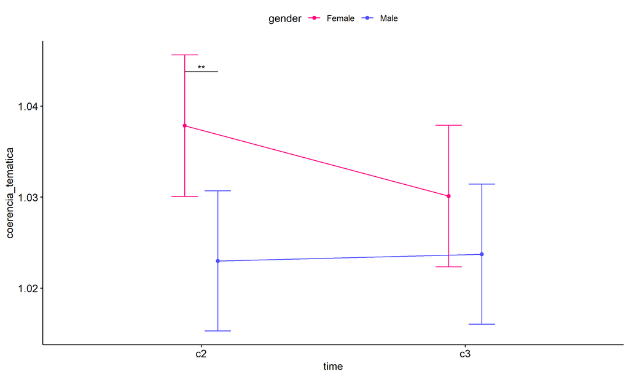

```r
pwc <- add_xy_position(pwc, x = "time", fun = "mean_se", dodge = 0.25)
pd <- position_dodge(width = 0.25)
ggline(emms, x = "time", y = "emmean", color = "gender",
       palette = c("#FF007F","#4D4DFF"),
       position = pd, ylab = "coerencia_tematica") +
  geom_errorbar(aes(ymin = conf.low, ymax = conf.high, color = gender),
                position = pd, width = 0.2) +
  stat_pvalue_manual(pwc, hide.ns = T, tip.length = F, linetype = 1)
```

```r
(pwc <- ldat %>% group_by(gender) %>%
    emmeans_test(coerencia_tematica ~ time, detailed = T, p.adjust.method = "bonferroni"))
```

```
## # A tibble: 2 × 15
##   gender term  .y.      group1 group2 null.value estimate      se    df conf.low
## * <fct>  <chr> <chr>    <chr>  <chr>       <dbl>    <dbl>   <dbl> <dbl>    <dbl>
## 1 Female time  coerenc… c2     c3              0  7.75e-3 0.00561  7582 -0.00325
## 2 Male   time  coerenc… c2     c3              0 -7.39e-4 0.00555  7582 -0.0116
## # ℹ 5 more variables: conf.high <dbl>, statistic <dbl>, p <dbl>, p.adj <dbl>,
## #   p.adj.signif <chr>
```

| gender | term | .y. | group1 | group2 | null.value | estimate | se | df | conf.low | conf.high | statistic | p | p.adj | p.adj.signif |
| --- | --- | --- | --- | --- | --- | --- | --- | --- | --- | --- | --- | --- | --- | --- |
| Female | time | coerencia_tematica | c2 | c3 | 0 | 0.008 | 0.006 | 7582 | -0.003 | 0.019 | 1.381 | 0.167 | 0.167 | ns |
| Male | time | coerencia_tematica | c2 | c3 | 0 | -0.001 | 0.006 | 7582 | -0.012 | 0.010 | -0.133 | 0.894 | 0.894 | ns |

```r
(emms <- get_emmeans(pwc))
```

```
## # A tibble: 4 × 8
##   gender time  emmean      se    df conf.low conf.high method
##   <fct>  <fct>  <dbl>   <dbl> <dbl>    <dbl>     <dbl> <chr>
## 1 Female c2      1.04 0.00397  7582     1.03      1.05 Emmeans test
## 2 Female c3      1.03 0.00397  7582     1.02      1.04 Emmeans test
## 3 Male   c2      1.02 0.00392  7582     1.02      1.03 Emmeans test
## 4 Male   c3      1.02 0.00392  7582     1.02      1.03 Emmeans test
```

| gender | time | emmean | se | df | conf.low | conf.high | method |
| --- | --- | --- | --- | --- | --- | --- | --- |
| Female | c2 | 1.038 | 0.004 | 7582 | 1.030 | 1.046 | Emmeans test |
| Female | c3 | 1.030 | 0.004 | 7582 | 1.022 | 1.038 | Emmeans test |
| Male | c2 | 1.023 | 0.004 | 7582 | 1.015 | 1.031 | Emmeans test |
| Male | c3 | 1.024 | 0.004 | 7582 | 1.016 | 1.031 | Emmeans test |

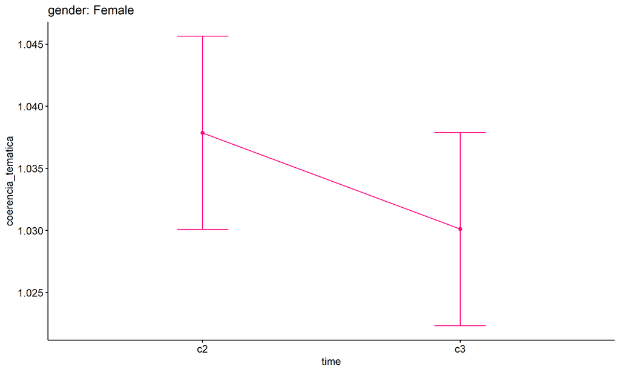

```r
emms.gg <- emms[which(emms$gender == "Female"),]
if (nrow(emms.gg) > 0)
  ggline(emms.gg, x = "time", y = "emmean", color = "#FF007F", ylab = "coerencia_tematica") +
    geom_errorbar(aes(ymin = conf.low, ymax = conf.high),
                  width = 0.2, color = "#FF007F") +
    stat_pvalue_manual(
      add_xy_position(pwc[which(pwc$gender == "Female"),],
                      x = "time", fun = "mean_se"),
      hide.ns = T, color = "#FF007F", tip.length = F) +
    labs(title = "gender: Female")+
    theme(legend.text = element_blank())
```

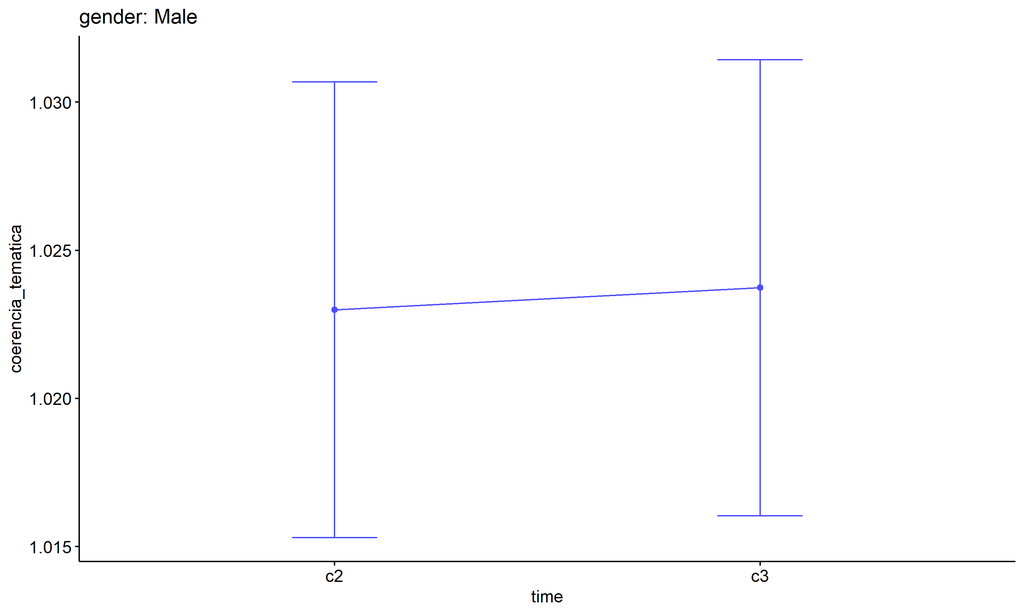

```r
emms.gg <- emms[which(emms$gender == "Male"),]
if (nrow(emms.gg) > 0)
  ggline(emms.gg, x = "time", y = "emmean", color = "#4D4DFF", ylab = "coerencia_tematica") +
    geom_errorbar(aes(ymin = conf.low, ymax = conf.high),
                  width = 0.2, color = "#4D4DFF") +
    stat_pvalue_manual(
      add_xy_position(pwc[which(pwc$gender == "Male"),],
                      x = "time", fun = "mean_se"),
      hide.ns = T, color = "#4D4DFF", tip.length = F) +
    labs(title = "gender: Male")+
    theme(legend.text = element_blank())
```

## PairWise Computation after removing non.normal data

```r
if (length(non.ids) > 0)
  (pwc2 <- ldat2 %>% group_by(time) %>%
     emmeans_test(coerencia_tematica ~ gender, detailed = T, p.adjust.method = "bonferroni"))
```

```r
if (length(non.ids) > 0)
  (emms2 <- get_emmeans(pwc2))
```

```r
if (length(non.ids) > 0) {
  pwc2 <- add_xy_position(pwc2, x = "time", fun = "mean_se", dodge = 0.25)
  pd2 <- position_dodge(width = 0.25)

  ggline(emms2, x = "time", y = "emmean", color = "gender",
         palette = c("#FF007F","#4D4DFF"),
         position = pd, ylab = "coerencia_tematica") +
    geom_errorbar(aes(ymin = conf.low, ymax = conf.high, color = gender),
                position = pd, width = 0.2) +
    stat_pvalue_manual(pwc2, hide.ns = T, tip.length = F, linetype = 1)
}
```

```r
if (length(non.ids) > 0)
  (pwc2 <- ldat2 %>% group_by(gender) %>%
     emmeans_test(coerencia_tematica ~ time, detailed = T, p.adjust.method = "bonferroni"))
```

```r
if (length(non.ids) > 0)
  (emms2 <- get_emmeans(pwc2))
```

```r
if (length(non.ids) > 0) {
  emms.gg <- emms2[which(emms2$gender == "Female"),]
  if (nrow(emms.gg) > 0)
    ggline(emms.gg, x = "time", y = "emmean", color = "#FF007F", ylab = "coerencia_tematica") +
    geom_errorbar(aes(ymin = conf.low, ymax = conf.high),
                  width = 0.2, color = "#FF007F") +
    stat_pvalue_manual(
      add_xy_position(pwc[which(pwc$gender == "Female"),],
                      x = "time", fun = "mean_se"),
      hide.ns = T, color = "#FF007F", tip.length = F) +
    labs(title = "gender: Female") +
    theme(legend.text = element_blank())
}
```

```r
if (length(non.ids) > 0) {
  emms.gg <- emms2[which(emms2$gender == "Male"),]
  if (nrow(emms.gg) > 0)
    ggline(emms.gg, x = "time", y = "emmean", color = "#4D4DFF", ylab = "coerencia_tematica") +
    geom_errorbar(aes(ymin = conf.low, ymax = conf.high),
                  width = 0.2, color = "#4D4DFF") +
    stat_pvalue_manual(
      add_xy_position(pwc[which(pwc$gender == "Male"),],
                      x = "time", fun = "mean_se"),
      hide.ns = T, color = "#4D4DFF", tip.length = F) +
    labs(title = "gender: Male") +
    theme(legend.text = element_blank())
}
```

# ANOVA: coerencia_tematica ~ time*localizacao + Error(id/time)

## Data Preparation

```r
data <- edat[,c("aluno_id","localizacao","ciclo","coerencia_tematica")]
data <- data[data$ciclo %in% c("Segundo Ciclo","Terceiro Ciclo"),]
data$ciclo <- factor(data$ciclo, c("Segundo Ciclo","Terceiro Ciclo"))
data <- unique(data)

wdat <- spread(data, ciclo, coerencia_tematica)
wdat <- wdat[complete.cases(wdat),]
colnames(wdat) <- c("id","localizacao","c2","c3")

ldat <- gather(wdat, key = time, value = coerencia_tematica, c2,c3) %>%
  convert_as_factor(id, time)
ldat <- remove_group_data(ldat, "coerencia_tematica", c("time", "localizacao"), n.limit = 30)
ldat$localizacao <- factor(ldat$localizacao, sort(unique(ldat$localizacao)))
```

### Check assumptions: Identifying Outliers

```r
outliers <- identify_outliers(group_by(ldat, time, localizacao), coerencia_tematica)
(outliers <- outliers[outliers$is.extreme == T,])
```

```
## # A tibble: 253 × 6
##    localizacao time  id                 coerencia_tematica is.outlier is.extreme
##    <fct>       <fct> <fct>                           <dbl> <lgl>      <lgl>
##  1 Rural       c2    cUepYSggkyNVXrET7…                2   TRUE       TRUE
##  2 Rural       c2    e4T8ur8rXZ7jH6myH…                2   TRUE       TRUE
##  3 Rural       c2    eMaYeLRiclZymf00B…                2   TRUE       TRUE
##  4 Rural       c2    gVuMjTLcSjwi8PtQc…                2   TRUE       TRUE
##  5 Rural       c2    hV78K1w2Sy3NbDijC…                2   TRUE       TRUE
##  6 Rural       c2    HW3iJR889Q9EdBWaQ…                1.5 TRUE       TRUE
##  7 Rural       c2    iYlYrwjNTF4uR2dhp…                1.5 TRUE       TRUE
##  8 Rural       c2    JKEvnqvCpv10PSAyc…                2   TRUE       TRUE
##  9 Rural       c2    ks4CBM3zPHocVr9Yl…                1.5 TRUE       TRUE
## 10 Rural       c2    lW5qykPQQcYd17PAf…                1.5 TRUE       TRUE
## # ℹ 243 more rows
```

| localizacao | time | id | coerencia_tematica | is.outlier | is.extreme |
| --- | --- | --- | --- | --- | --- |
| Rural | c2 | cUepYSggkyNVXrET7RCr | 2.000 | TRUE | TRUE |
| Rural | c2 | e4T8ur8rXZ7jH6myH0wq | 2.000 | TRUE | TRUE |
| Rural | c2 | eMaYeLRiclZymf00Bgj3 | 2.000 | TRUE | TRUE |
| Rural | c2 | gVuMjTLcSjwi8PtQcX3g | 2.000 | TRUE | TRUE |
| Rural | c2 | hV78K1w2Sy3NbDijChE1 | 2.000 | TRUE | TRUE |
| Rural | c2 | HW3iJR889Q9EdBWaQrFP | 1.500 | TRUE | TRUE |
| Rural | c2 | iYlYrwjNTF4uR2dhpyxO | 1.500 | TRUE | TRUE |
| Rural | c2 | JKEvnqvCpv10PSAycuzr | 2.000 | TRUE | TRUE |
| Rural | c2 | ks4CBM3zPHocVr9YlWDI | 1.500 | TRUE | TRUE |
| Rural | c2 | lW5qykPQQcYd17PAfD2m | 1.500 | TRUE | TRUE |
| Rural | c2 | N4IaRiNre0zdlO8WMnpU | 1.500 | TRUE | TRUE |
| Rural | c2 | NhAQ8t5HSuELn12vygjO | 2.000 | TRUE | TRUE |
| Rural | c2 | oEDVJwdVHdc8vvUBo2jy | 3.000 | TRUE | TRUE |
| Rural | c2 | oiwBh6qBV0OXX5Ky4pUT | 2.000 | TRUE | TRUE |
| Rural | c2 | PQBj15ebjZg4nyeHd9e4 | 3.000 | TRUE | TRUE |
| Rural | c2 | ptWlwZXM3ojHCTykyYEJ | 1.500 | TRUE | TRUE |
| Rural | c2 | puJ0cHDwxp3cYxetrMyX | 2.000 | TRUE | TRUE |
| Rural | c2 | qmI2dE4LuX6CGzXwWF7F | 2.000 | TRUE | TRUE |
| Rural | c2 | QX1AYFz0937xfLHeuBgs | 2.000 | TRUE | TRUE |
| Rural | c2 | sqswiqzkWZWmnp3PhqTw | 1.500 | TRUE | TRUE |
| Rural | c2 | T4FHGCkWdtu0VECvhUzE | 1.500 | TRUE | TRUE |
| Rural | c2 | u0hPBK1IAHuD6dO6zj4d | 2.000 | TRUE | TRUE |
| Rural | c2 | Vp1uLMoHAG4q1y7fsjcA | 1.500 | TRUE | TRUE |
| Rural | c2 | XX5eGVd1Hbd37UnSUG7o | 2.000 | TRUE | TRUE |
| Rural | c2 | yYPvU7v7STKRyATXYjci | 1.500 | TRUE | TRUE |
| Rural | c2 | zyjVeK0oD3vhd93yTzBU | 2.000 | TRUE | TRUE |
| Urbana | c2 | a8SWsJUcxVnZgfDuYhl9 | 1.500 | TRUE | TRUE |
| Urbana | c2 | aGe8oY0BM2o4WY2b3cMO | 1.500 | TRUE | TRUE |
| Urbana | c2 | aHRArOnxnMCJAnjRvMkz | 1.500 | TRUE | TRUE |
| Urbana | c2 | bBBGsbvYBLgWujzEuOES | 2.000 | TRUE | TRUE |

[output cut: 223 more lines]

### Check assumptions: Normality Test

```r
(normality.df <- normality.test.per.groups(ldat, "coerencia_tematica", c("time", "localizacao")))
```

```
##                  var           variable time localizacao    n skewness kurtosis
## 1 coerencia_tematica coerencia_tematica   c2       Rural  701 6.595956 49.91027
## 2 coerencia_tematica coerencia_tematica   c2      Urbana 3341 6.714515 51.37492
## 3 coerencia_tematica coerencia_tematica   c3       Rural  701 6.594436 47.61826
## 4 coerencia_tematica coerencia_tematica   c3      Urbana 3341 6.676573 48.50163
##   symmetry statistic     method p p.signif normality
## 1       NO  887.9807 D'Agostino 0     ****         -
## 2       NO 4082.4640 D'Agostino 0     ****         -
## 3       NO  884.5446 D'Agostino 0     ****         -
## 4       NO 4052.8711 D'Agostino 0     ****         -
```

| var | variable | time | localizacao | n | skewness | kurtosis | symmetry | statistic | method | p | p.signif | normality |
| --- | --- | --- | --- | --- | --- | --- | --- | --- | --- | --- | --- | --- |
| coerencia_tematica | coerencia_tematica | c2 | Rural | 701 | 6.596 | 49.910 | NO | 887.981 | D’Agostino | 0 | **** | - |
| coerencia_tematica | coerencia_tematica | c2 | Urbana | 3341 | 6.715 | 51.375 | NO | 4082.464 | D’Agostino | 0 | **** | - |
| coerencia_tematica | coerencia_tematica | c3 | Rural | 701 | 6.594 | 47.618 | NO | 884.545 | D’Agostino | 0 | **** | - |
| coerencia_tematica | coerencia_tematica | c3 | Urbana | 3341 | 6.677 | 48.502 | NO | 4052.871 | D’Agostino | 0 | **** | - |

```r
(non.ids <- unique(do.call(
  c, lapply(which(normality.df$normality == 'NO'), FUN = function(i) {
  idx = which(ldat$time == normality.df$time[i] &
                ldat$localizacao == normality.df$localizacao[i])
  getNonNormal(ldat$"coerencia_tematica"[idx], ldat$id[idx])
}))))
```

```r
if (length(non.ids) > 0)
  ldat2 <- ldat[!ldat$id %in% non.ids,]
```

### Summary Statistics

```r
(sdat <- ldat %>% group_by(time, localizacao) %>%
   get_summary_stats(coerencia_tematica, type = "mean_sd"))
```

```
## # A tibble: 4 × 6
##   localizacao time  variable               n  mean    sd
##   <fct>       <fct> <fct>              <dbl> <dbl> <dbl>
## 1 Rural       c2    coerencia_tematica   701  1.03 0.184
## 2 Urbana      c2    coerencia_tematica  3341  1.03 0.171
## 3 Rural       c3    coerencia_tematica   701  1.03 0.17
## 4 Urbana      c3    coerencia_tematica  3341  1.03 0.171
```

| localizacao | time | variable | n | mean | sd |
| --- | --- | --- | --- | --- | --- |
| Rural | c2 | coerencia_tematica | 701 | 1.033 | 0.184 |
| Urbana | c2 | coerencia_tematica | 3341 | 1.030 | 0.171 |
| Rural | c3 | coerencia_tematica | 701 | 1.028 | 0.170 |
| Urbana | c3 | coerencia_tematica | 3341 | 1.027 | 0.171 |

```r
if (length(non.ids) > 0)
  (sdat <- ldat2 %>% group_by(time, localizacao) %>%
      get_summary_stats(coerencia_tematica, type = "mean_sd"))
```

| localizacao | time | variable | n | mean | sd |
| --- | --- | --- | --- | --- | --- |
| Rural | c2 | coerencia_tematica | 701 | 1.033 | 0.184 |
| Urbana | c2 | coerencia_tematica | 3341 | 1.030 | 0.171 |
| Rural | c3 | coerencia_tematica | 701 | 1.028 | 0.170 |
| Urbana | c3 | coerencia_tematica | 3341 | 1.027 | 0.171 |

## ANOVA Computation

```r
(res.aov <- anova_test(ldat, dv = coerencia_tematica, wid = id, between = localizacao, within = time))
```

```
## ANOVA Table (type III tests)
##
##             Effect DFn  DFd     F     p p<.05      ges
## 1      localizacao   1 4040 0.111 0.739       1.55e-05
## 2             time   1 4040 0.593 0.441       6.41e-05
## 3 localizacao:time   1 4040 0.083 0.774       8.92e-06
```

## ANOVA Computation after removing non.normal data

```r
if (length(non.ids) > 0)
  (res.aov2 <- anova_test(ldat2, dv = coerencia_tematica, wid = id, between = localizacao , within = time))
```

## PairWise Computation

```r
(pwc <- ldat %>% group_by(time) %>%
   emmeans_test(coerencia_tematica ~ localizacao, detailed = T, p.adjust.method = "bonferroni"))
```

```
## # A tibble: 2 × 15
##   time  term      .y.   group1 group2 null.value estimate      se    df conf.low
## * <fct> <chr>     <chr> <chr>  <chr>       <dbl>    <dbl>   <dbl> <dbl>    <dbl>
## 1 c2    localiza… coer… Rural  Urbana          0 0.00314  0.00715  8080  -0.0109
## 2 c3    localiza… coer… Rural  Urbana          0 0.000430 0.00715  8080  -0.0136
## # ℹ 5 more variables: conf.high <dbl>, statistic <dbl>, p <dbl>, p.adj <dbl>,
## #   p.adj.signif <chr>
```

| time | term | .y. | group1 | group2 | null.value | estimate | se | df | conf.low | conf.high | statistic | p | p.adj | p.adj.signif |
| --- | --- | --- | --- | --- | --- | --- | --- | --- | --- | --- | --- | --- | --- | --- |
| c2 | localizacao | coerencia_tematica | Rural | Urbana | 0 | 0.003 | 0.007 | 8080 | -0.011 | 0.017 | 0.44 | 0.660 | 0.660 | ns |
| c3 | localizacao | coerencia_tematica | Rural | Urbana | 0 | 0.000 | 0.007 | 8080 | -0.014 | 0.014 | 0.06 | 0.952 | 0.952 | ns |

```r
(emms <- get_emmeans(pwc))
```

```
## # A tibble: 4 × 8
##   time  localizacao emmean      se    df conf.low conf.high method
##   <fct> <fct>        <dbl>   <dbl> <dbl>    <dbl>     <dbl> <chr>
## 1 c2    Rural         1.03 0.00650  8080     1.02      1.05 Emmeans test
## 2 c2    Urbana        1.03 0.00298  8080     1.02      1.04 Emmeans test
## 3 c3    Rural         1.03 0.00650  8080     1.02      1.04 Emmeans test
## 4 c3    Urbana        1.03 0.00298  8080     1.02      1.03 Emmeans test
```

| time | localizacao | emmean | se | df | conf.low | conf.high | method |
| --- | --- | --- | --- | --- | --- | --- | --- |
| c2 | Rural | 1.033 | 0.006 | 8080 | 1.020 | 1.046 | Emmeans test |
| c2 | Urbana | 1.030 | 0.003 | 8080 | 1.024 | 1.036 | Emmeans test |
| c3 | Rural | 1.028 | 0.006 | 8080 | 1.015 | 1.041 | Emmeans test |
| c3 | Urbana | 1.027 | 0.003 | 8080 | 1.022 | 1.033 | Emmeans test |

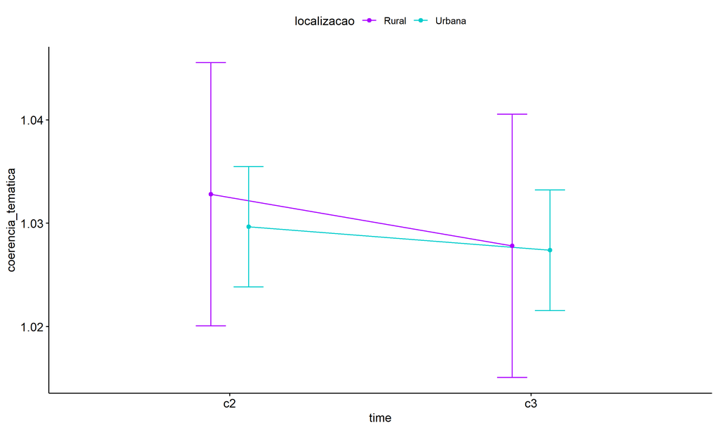

```r
pwc <- add_xy_position(pwc, x = "time", fun = "mean_se", dodge = 0.25)
pd <- position_dodge(width = 0.25)
ggline(emms, x = "time", y = "emmean", color = "localizacao",
       palette = c("#AA00FF","#00CCCC"),
       position = pd, ylab = "coerencia_tematica") +
  geom_errorbar(aes(ymin = conf.low, ymax = conf.high, color = localizacao),
                position = pd, width = 0.2) +
  stat_pvalue_manual(pwc, hide.ns = T, tip.length = F, linetype = 1)
```

```r
(pwc <- ldat %>% group_by(localizacao) %>%
    emmeans_test(coerencia_tematica ~ time, detailed = T, p.adjust.method = "bonferroni"))
```

```
## # A tibble: 2 × 15
##   localizacao term  .y.          group1 group2 null.value estimate      se    df
## * <fct>       <chr> <chr>        <chr>  <chr>       <dbl>    <dbl>   <dbl> <dbl>
## 1 Rural       time  coerencia_t… c2     c3              0  0.00499 0.00919  8080
## 2 Urbana      time  coerencia_t… c2     c3              0  0.00228 0.00421  8080
## # ℹ 6 more variables: conf.low <dbl>, conf.high <dbl>, statistic <dbl>,
## #   p <dbl>, p.adj <dbl>, p.adj.signif <chr>
```

| localizacao | term | .y. | group1 | group2 | null.value | estimate | se | df | conf.low | conf.high | statistic | p | p.adj | p.adj.signif |
| --- | --- | --- | --- | --- | --- | --- | --- | --- | --- | --- | --- | --- | --- | --- |
| Rural | time | coerencia_tematica | c2 | c3 | 0 | 0.005 | 0.009 | 8080 | -0.013 | 0.023 | 0.543 | 0.587 | 0.587 | ns |
| Urbana | time | coerencia_tematica | c2 | c3 | 0 | 0.002 | 0.004 | 8080 | -0.006 | 0.011 | 0.542 | 0.588 | 0.588 | ns |

```r
(emms <- get_emmeans(pwc))
```

```
## # A tibble: 4 × 8
##   localizacao time  emmean      se    df conf.low conf.high method
##   <fct>       <fct>  <dbl>   <dbl> <dbl>    <dbl>     <dbl> <chr>
## 1 Rural       c2      1.03 0.00650  8080     1.02      1.05 Emmeans test
## 2 Rural       c3      1.03 0.00650  8080     1.02      1.04 Emmeans test
## 3 Urbana      c2      1.03 0.00298  8080     1.02      1.04 Emmeans test
## 4 Urbana      c3      1.03 0.00298  8080     1.02      1.03 Emmeans test
```

| localizacao | time | emmean | se | df | conf.low | conf.high | method |
| --- | --- | --- | --- | --- | --- | --- | --- |
| Rural | c2 | 1.033 | 0.006 | 8080 | 1.020 | 1.046 | Emmeans test |
| Rural | c3 | 1.028 | 0.006 | 8080 | 1.015 | 1.041 | Emmeans test |
| Urbana | c2 | 1.030 | 0.003 | 8080 | 1.024 | 1.036 | Emmeans test |
| Urbana | c3 | 1.027 | 0.003 | 8080 | 1.022 | 1.033 | Emmeans test |

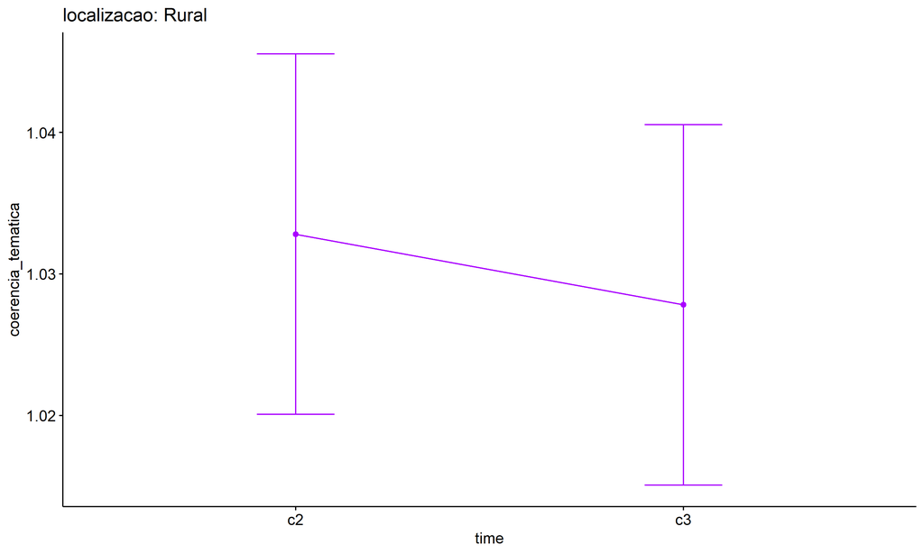

```r
emms.gg <- emms[which(emms$localizacao == "Rural"),]
if (nrow(emms.gg) > 0)
  ggline(emms.gg, x = "time", y = "emmean", color = "#AA00FF", ylab = "coerencia_tematica") +
    geom_errorbar(aes(ymin = conf.low, ymax = conf.high),
                  width = 0.2, color = "#AA00FF") +
    stat_pvalue_manual(
      add_xy_position(pwc[which(pwc$localizacao == "Rural"),],
                      x = "time", fun = "mean_se"),
      hide.ns = T, color = "#AA00FF", tip.length = F) +
    labs(title = "localizacao: Rural")+
    theme(legend.text = element_blank())
```

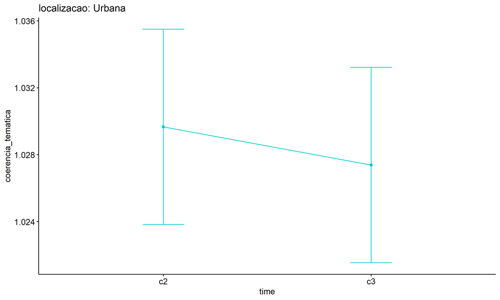

```r
emms.gg <- emms[which(emms$localizacao == "Urbana"),]
if (nrow(emms.gg) > 0)
  ggline(emms.gg, x = "time", y = "emmean", color = "#00CCCC", ylab = "coerencia_tematica") +
    geom_errorbar(aes(ymin = conf.low, ymax = conf.high),
                  width = 0.2, color = "#00CCCC") +
    stat_pvalue_manual(
      add_xy_position(pwc[which(pwc$localizacao == "Urbana"),],
                      x = "time", fun = "mean_se"),
      hide.ns = T, color = "#00CCCC", tip.length = F) +
    labs(title = "localizacao: Urbana")+
    theme(legend.text = element_blank())
```

## PairWise Computation after removing non.normal data

```r
if (length(non.ids) > 0)
  (pwc2 <- ldat2 %>% group_by(time) %>%
     emmeans_test(coerencia_tematica ~ localizacao, detailed = T, p.adjust.method = "bonferroni"))
```

```r
if (length(non.ids) > 0)
  (emms2 <- get_emmeans(pwc2))
```

```r
if (length(non.ids) > 0) {
  pwc2 <- add_xy_position(pwc2, x = "time", fun = "mean_se", dodge = 0.25)
  pd2 <- position_dodge(width = 0.25)

  ggline(emms2, x = "time", y = "emmean", color = "localizacao",
         palette = c("#AA00FF","#00CCCC"),
         position = pd, ylab = "coerencia_tematica") +
    geom_errorbar(aes(ymin = conf.low, ymax = conf.high, color = localizacao),
                position = pd, width = 0.2) +
    stat_pvalue_manual(pwc2, hide.ns = T, tip.length = F, linetype = 1)
}
```

```r
if (length(non.ids) > 0)
  (pwc2 <- ldat2 %>% group_by(localizacao) %>%
     emmeans_test(coerencia_tematica ~ time, detailed = T, p.adjust.method = "bonferroni"))
```

```r
if (length(non.ids) > 0)
  (emms2 <- get_emmeans(pwc2))
```

```r
if (length(non.ids) > 0) {
  emms.gg <- emms2[which(emms2$localizacao == "Rural"),]
  if (nrow(emms.gg) > 0)
    ggline(emms.gg, x = "time", y = "emmean", color = "#AA00FF", ylab = "coerencia_tematica") +
    geom_errorbar(aes(ymin = conf.low, ymax = conf.high),
                  width = 0.2, color = "#AA00FF") +
    stat_pvalue_manual(
      add_xy_position(pwc[which(pwc$localizacao == "Rural"),],
                      x = "time", fun = "mean_se"),
      hide.ns = T, color = "#AA00FF", tip.length = F) +
    labs(title = "localizacao: Rural") +
    theme(legend.text = element_blank())
}
```

```r
if (length(non.ids) > 0) {
  emms.gg <- emms2[which(emms2$localizacao == "Urbana"),]
  if (nrow(emms.gg) > 0)
    ggline(emms.gg, x = "time", y = "emmean", color = "#00CCCC", ylab = "coerencia_tematica") +
    geom_errorbar(aes(ymin = conf.low, ymax = conf.high),
                  width = 0.2, color = "#00CCCC") +
    stat_pvalue_manual(
      add_xy_position(pwc[which(pwc$localizacao == "Urbana"),],
                      x = "time", fun = "mean_se"),
      hide.ns = T, color = "#00CCCC", tip.length = F) +
    labs(title = "localizacao: Urbana") +
    theme(legend.text = element_blank())
}
```

# ANOVA: coerencia_tematica ~ time*regiao + Error(id/time)

## Data Preparation

```r
data <- edat[,c("aluno_id","regiao","ciclo","coerencia_tematica")]
data <- data[data$ciclo %in% c("Segundo Ciclo","Terceiro Ciclo"),]
data$ciclo <- factor(data$ciclo, c("Segundo Ciclo","Terceiro Ciclo"))
data <- unique(data)

wdat <- spread(data, ciclo, coerencia_tematica)
wdat <- wdat[complete.cases(wdat),]
colnames(wdat) <- c("id","regiao","c2","c3")

ldat <- gather(wdat, key = time, value = coerencia_tematica, c2,c3) %>%
  convert_as_factor(id, time)
ldat <- remove_group_data(ldat, "coerencia_tematica", c("time", "regiao"), n.limit = 30)
ldat$regiao <- factor(ldat$regiao, sort(unique(ldat$regiao)))
```

### Check assumptions: Identifying Outliers

```r
outliers <- identify_outliers(group_by(ldat, time, regiao), coerencia_tematica)
(outliers <- outliers[outliers$is.extreme == T,])
```

```
## # A tibble: 253 × 6
##    regiao       time  id                coerencia_tematica is.outlier is.extreme
##    <fct>        <fct> <fct>                          <dbl> <lgl>      <lgl>
##  1 Centro-Oeste c2    gSjPJJEtnEyiq3yE…                2   TRUE       TRUE
##  2 Centro-Oeste c2    GyXkNYglZFaiWPdo…                1.5 TRUE       TRUE
##  3 Centro-Oeste c2    Pt8nmYgqUGtYaso9…                2   TRUE       TRUE
##  4 Centro-Oeste c2    w2KWF4yz1Qt8S6ap…                2   TRUE       TRUE
##  5 Centro-Oeste c2    ZDZhpODoVH9TsZis…                2   TRUE       TRUE
##  6 Nordeste     c2    bBBGsbvYBLgWujzE…                2   TRUE       TRUE
##  7 Nordeste     c2    c8tCs09Zmla9HW6n…                1.5 TRUE       TRUE
##  8 Nordeste     c2    cFxwLMwyCxWzWrkp…                3   TRUE       TRUE
##  9 Nordeste     c2    cO1stoI0XTZlXCGz…                1.5 TRUE       TRUE
## 10 Nordeste     c2    cUepYSggkyNVXrET…                2   TRUE       TRUE
## # ℹ 243 more rows
```

| regiao | time | id | coerencia_tematica | is.outlier | is.extreme |
| --- | --- | --- | --- | --- | --- |
| Centro-Oeste | c2 | gSjPJJEtnEyiq3yEKqic | 2.000 | TRUE | TRUE |
| Centro-Oeste | c2 | GyXkNYglZFaiWPdo2jHx | 1.500 | TRUE | TRUE |
| Centro-Oeste | c2 | Pt8nmYgqUGtYaso9qysz | 2.000 | TRUE | TRUE |
| Centro-Oeste | c2 | w2KWF4yz1Qt8S6apg9Nq | 2.000 | TRUE | TRUE |
| Centro-Oeste | c2 | ZDZhpODoVH9TsZisJTN4 | 2.000 | TRUE | TRUE |
| Nordeste | c2 | bBBGsbvYBLgWujzEuOES | 2.000 | TRUE | TRUE |
| Nordeste | c2 | c8tCs09Zmla9HW6nXAba | 1.500 | TRUE | TRUE |
| Nordeste | c2 | cFxwLMwyCxWzWrkpwvkt | 3.000 | TRUE | TRUE |
| Nordeste | c2 | cO1stoI0XTZlXCGzSYmR | 1.500 | TRUE | TRUE |
| Nordeste | c2 | cUepYSggkyNVXrET7RCr | 2.000 | TRUE | TRUE |
| Nordeste | c2 | dzxWSwAxb1LbKLWq0f8W | 2.000 | TRUE | TRUE |
| Nordeste | c2 | e4T8ur8rXZ7jH6myH0wq | 2.000 | TRUE | TRUE |
| Nordeste | c2 | eakSXIhde0LSciiZKTJf | 1.500 | TRUE | TRUE |
| Nordeste | c2 | eMaYeLRiclZymf00Bgj3 | 2.000 | TRUE | TRUE |
| Nordeste | c2 | g2V94DT753T4rGOFLnO9 | 3.000 | TRUE | TRUE |
| Nordeste | c2 | gcpsjKSQtozLkdeuPlAQ | 1.500 | TRUE | TRUE |
| Nordeste | c2 | higntdffAusBUEJvytQY | 2.000 | TRUE | TRUE |
| Nordeste | c2 | hOPnyViTC3bVUvYv9zCC | 1.500 | TRUE | TRUE |
| Nordeste | c2 | HuD1YErYaPFPc5BeAVhI | 2.000 | TRUE | TRUE |
| Nordeste | c2 | hV78K1w2Sy3NbDijChE1 | 2.000 | TRUE | TRUE |
| Nordeste | c2 | HW3iJR889Q9EdBWaQrFP | 1.500 | TRUE | TRUE |
| Nordeste | c2 | iGhiHBHlWPESJbq2D7PI | 2.000 | TRUE | TRUE |
| Nordeste | c2 | ILuG2m3xDKcwiThmAUW8 | 2.000 | TRUE | TRUE |
| Nordeste | c2 | INm50SKxqFJZGliYbYuq | 2.000 | TRUE | TRUE |
| Nordeste | c2 | IOvrLhjyL36foBOflXwo | 2.000 | TRUE | TRUE |
| Nordeste | c2 | ITPXRLN2xaGJzebM4a3K | 1.500 | TRUE | TRUE |
| Nordeste | c2 | j29T3ZFdMcWxbBYVneR1 | 2.000 | TRUE | TRUE |
| Nordeste | c2 | j8nYm0EY03K9FNADOg7A | 2.000 | TRUE | TRUE |
| Nordeste | c2 | jqYuNJZAsKjE34sLcEiN | 2.000 | TRUE | TRUE |
| Nordeste | c2 | kJIRWfRQpGpgJ9XydSAv | 2.000 | TRUE | TRUE |

[output cut: 223 more lines]

### Check assumptions: Normality Test

```r
(normality.df <- normality.test.per.groups(ldat, "coerencia_tematica", c("time", "regiao")))
```

```
##                   var           variable time       regiao    n skewness
## 1  coerencia_tematica coerencia_tematica   c2 Centro-Oeste  198 0.000000
## 2  coerencia_tematica coerencia_tematica   c2     Nordeste 1464 5.506897
## 3  coerencia_tematica coerencia_tematica   c2        Norte  435 7.117844
## 4  coerencia_tematica coerencia_tematica   c2      Sudeste 1473 7.431643
## 5  coerencia_tematica coerencia_tematica   c2          Sul  472 9.930828
## 6  coerencia_tematica coerencia_tematica   c3 Centro-Oeste  198 0.000000
## 7  coerencia_tematica coerencia_tematica   c3     Nordeste 1464 5.991361
## 8  coerencia_tematica coerencia_tematica   c3        Norte  435 0.000000
## 9  coerencia_tematica coerencia_tematica   c3      Sudeste 1473 7.116142
## 10 coerencia_tematica coerencia_tematica   c3          Sul  472 0.000000
##     kurtosis symmetry statistic     method p p.signif normality
## 1    0.00000 few data        NA       <NA> 1     <NA>        NO
## 2   34.12464       NO 1582.8898 D'Agostino 0     ****         -
## 3   57.66763       NO  599.6824 D'Agostino 0     ****         -
## 4   63.43495       NO 1954.5485 D'Agostino 0     ****         -
## 5  110.04289       NO  788.6359 D'Agostino 0     ****         -
## 6    0.00000 few data        NA       <NA> 1     <NA>        NO
## 7   38.97698       NO 1675.8951 D'Agostino 0     ****         -
## 8    0.00000 few data        NA       <NA> 1     <NA>        NO
## 9   55.55304       NO 1894.8488 D'Agostino 0     ****         -
## 10   0.00000 few data        NA       <NA> 1     <NA>        NO
```

| var | variable | time | regiao | n | skewness | kurtosis | symmetry | statistic | method | p | p.signif | normality |
| --- | --- | --- | --- | --- | --- | --- | --- | --- | --- | --- | --- | --- |
| coerencia_tematica | coerencia_tematica | c2 | Centro-Oeste | 198 | 0.000 | 0.000 | few data | NA | NA | 1 | NA | NO |
| coerencia_tematica | coerencia_tematica | c2 | Nordeste | 1464 | 5.507 | 34.125 | NO | 1582.890 | D’Agostino | 0 | **** | - |
| coerencia_tematica | coerencia_tematica | c2 | Norte | 435 | 7.118 | 57.668 | NO | 599.682 | D’Agostino | 0 | **** | - |
| coerencia_tematica | coerencia_tematica | c2 | Sudeste | 1473 | 7.432 | 63.435 | NO | 1954.549 | D’Agostino | 0 | **** | - |
| coerencia_tematica | coerencia_tematica | c2 | Sul | 472 | 9.931 | 110.043 | NO | 788.636 | D’Agostino | 0 | **** | - |
| coerencia_tematica | coerencia_tematica | c3 | Centro-Oeste | 198 | 0.000 | 0.000 | few data | NA | NA | 1 | NA | NO |
| coerencia_tematica | coerencia_tematica | c3 | Nordeste | 1464 | 5.991 | 38.977 | NO | 1675.895 | D’Agostino | 0 | **** | - |
| coerencia_tematica | coerencia_tematica | c3 | Norte | 435 | 0.000 | 0.000 | few data | NA | NA | 1 | NA | NO |
| coerencia_tematica | coerencia_tematica | c3 | Sudeste | 1473 | 7.116 | 55.553 | NO | 1894.849 | D’Agostino | 0 | **** | - |
| coerencia_tematica | coerencia_tematica | c3 | Sul | 472 | 0.000 | 0.000 | few data | NA | NA | 1 | NA | NO |

```r
(non.ids <- unique(do.call(
  c, lapply(which(normality.df$normality == 'NO'), FUN = function(i) {
  idx = which(ldat$time == normality.df$time[i] &
                ldat$regiao == normality.df$regiao[i])
  getNonNormal(ldat$"coerencia_tematica"[idx], ldat$id[idx])
}))))
```

```r
if (length(non.ids) > 0)
  ldat2 <- ldat[!ldat$id %in% non.ids,]
```

### Summary Statistics

```r
(sdat <- ldat %>% group_by(time, regiao) %>%
   get_summary_stats(coerencia_tematica, type = "mean_sd"))
```

```
## # A tibble: 10 × 6
##    regiao       time  variable               n  mean    sd
##    <fct>        <fct> <fct>              <dbl> <dbl> <dbl>
##  1 Centro-Oeste c2    coerencia_tematica   198  1.02 0.145
##  2 Nordeste     c2    coerencia_tematica  1464  1.05 0.219
##  3 Norte        c2    coerencia_tematica   435  1.03 0.171
##  4 Sudeste      c2    coerencia_tematica  1473  1.02 0.14
##  5 Sul          c2    coerencia_tematica   472  1.01 0.107
##  6 Centro-Oeste c3    coerencia_tematica   198  1.03 0.161
##  7 Nordeste     c3    coerencia_tematica  1464  1.03 0.191
##  8 Norte        c3    coerencia_tematica   435  1.02 0.143
##  9 Sudeste      c3    coerencia_tematica  1473  1.02 0.161
## 10 Sul          c3    coerencia_tematica   472  1.03 0.159
```

| regiao | time | variable | n | mean | sd |
| --- | --- | --- | --- | --- | --- |
| Centro-Oeste | c2 | coerencia_tematica | 198 | 1.023 | 0.145 |
| Nordeste | c2 | coerencia_tematica | 1464 | 1.046 | 0.219 |
| Norte | c2 | coerencia_tematica | 435 | 1.028 | 0.171 |
| Sudeste | c2 | coerencia_tematica | 1473 | 1.022 | 0.140 |
| Sul | c2 | coerencia_tematica | 472 | 1.013 | 0.107 |
| Centro-Oeste | c3 | coerencia_tematica | 198 | 1.028 | 0.161 |
| Nordeste | c3 | coerencia_tematica | 1464 | 1.034 | 0.191 |
| Norte | c3 | coerencia_tematica | 435 | 1.016 | 0.143 |
| Sudeste | c3 | coerencia_tematica | 1473 | 1.024 | 0.161 |
| Sul | c3 | coerencia_tematica | 472 | 1.026 | 0.159 |

```r
if (length(non.ids) > 0)
  (sdat <- ldat2 %>% group_by(time, regiao) %>%
      get_summary_stats(coerencia_tematica, type = "mean_sd"))
```

| regiao | time | variable | n | mean | sd |
| --- | --- | --- | --- | --- | --- |
| Centro-Oeste | c2 | coerencia_tematica | 198 | 1.023 | 0.145 |
| Nordeste | c2 | coerencia_tematica | 1464 | 1.046 | 0.219 |
| Norte | c2 | coerencia_tematica | 435 | 1.028 | 0.171 |
| Sudeste | c2 | coerencia_tematica | 1473 | 1.022 | 0.140 |
| Sul | c2 | coerencia_tematica | 472 | 1.013 | 0.107 |
| Centro-Oeste | c3 | coerencia_tematica | 198 | 1.028 | 0.161 |
| Nordeste | c3 | coerencia_tematica | 1464 | 1.034 | 0.191 |
| Norte | c3 | coerencia_tematica | 435 | 1.016 | 0.143 |
| Sudeste | c3 | coerencia_tematica | 1473 | 1.024 | 0.161 |
| Sul | c3 | coerencia_tematica | 472 | 1.026 | 0.159 |

## ANOVA Computation

```r
(res.aov <- anova_test(ldat, dv = coerencia_tematica, wid = id, between = regiao, within = time))
```

```
## ANOVA Table (type III tests)
##
##        Effect DFn  DFd     F     p p<.05      ges
## 1      regiao   4 4037 4.373 0.002     * 2.00e-03
## 2        time   1 4037 0.007 0.933       7.65e-07
## 3 regiao:time   4 4037 1.581 0.176       6.85e-04
```

## ANOVA Computation after removing non.normal data

```r
if (length(non.ids) > 0)
  (res.aov2 <- anova_test(ldat2, dv = coerencia_tematica, wid = id, between = regiao , within = time))
```

## PairWise Computation

```r
(pwc <- ldat %>% group_by(time) %>%
   emmeans_test(coerencia_tematica ~ regiao, detailed = T, p.adjust.method = "bonferroni"))
```

| time | term | .y. | group1 | group2 | null.value | estimate | se | df | conf.low | conf.high | statistic | p | p.adj | p.adj.signif |
| --- | --- | --- | --- | --- | --- | --- | --- | --- | --- | --- | --- | --- | --- | --- |
| c2 | regiao | coerencia_tematica | Centro | Oeste | 0 | -0.023 | 0.013 | 8074 | -0.049 | 0.002 | -1.771 | 0.077 | 0.766 | ns |
| c2 | regiao | coerencia_tematica | Centro | Oeste | 0 | -0.005 | 0.015 | 8074 | -0.034 | 0.024 | -0.330 | 0.741 | 1.000 | ns |
| c2 | regiao | coerencia_tematica | Centro | Oeste | 0 | 0.001 | 0.013 | 8074 | -0.025 | 0.026 | 0.045 | 0.964 | 1.000 | ns |
| c2 | regiao | coerencia_tematica | Centro | Oeste | 0 | 0.010 | 0.015 | 8074 | -0.019 | 0.039 | 0.688 | 0.491 | 1.000 | ns |
| c2 | regiao | coerencia_tematica | Nordeste | Norte | 0 | 0.018 | 0.009 | 8074 | 0.000 | 0.037 | 1.938 | 0.053 | 0.527 | ns |
| c2 | regiao | coerencia_tematica | Nordeste | Sudeste | 0 | 0.024 | 0.006 | 8074 | 0.011 | 0.036 | 3.725 | 0.000 | 0.002 | ** |
| c2 | regiao | coerencia_tematica | Nordeste | Sul | 0 | 0.033 | 0.009 | 8074 | 0.015 | 0.051 | 3.635 | 0.000 | 0.003 | ** |
| c2 | regiao | coerencia_tematica | Norte | Sudeste | 0 | 0.005 | 0.009 | 8074 | -0.013 | 0.024 | 0.581 | 0.562 | 1.000 | ns |
| c2 | regiao | coerencia_tematica | Norte | Sul | 0 | 0.015 | 0.011 | 8074 | -0.008 | 0.037 | 1.303 | 0.193 | 1.000 | ns |
| c2 | regiao | coerencia_tematica | Sudeste | Sul | 0 | 0.009 | 0.009 | 8074 | -0.008 | 0.027 | 1.038 | 0.299 | 1.000 | ns |
| c3 | regiao | coerencia_tematica | Centro | Oeste | 0 | -0.006 | 0.013 | 8074 | -0.032 | 0.019 | -0.490 | 0.624 | 1.000 | ns |
| c3 | regiao | coerencia_tematica | Centro | Oeste | 0 | 0.012 | 0.015 | 8074 | -0.017 | 0.041 | 0.793 | 0.428 | 1.000 | ns |
| c3 | regiao | coerencia_tematica | Centro | Oeste | 0 | 0.003 | 0.013 | 8074 | -0.022 | 0.029 | 0.257 | 0.797 | 1.000 | ns |
| c3 | regiao | coerencia_tematica | Centro | Oeste | 0 | 0.001 | 0.015 | 8074 | -0.027 | 0.030 | 0.089 | 0.929 | 1.000 | ns |
| c3 | regiao | coerencia_tematica | Nordeste | Norte | 0 | 0.018 | 0.009 | 8074 | 0.000 | 0.036 | 1.925 | 0.054 | 0.543 | ns |
| c3 | regiao | coerencia_tematica | Nordeste | Sudeste | 0 | 0.010 | 0.006 | 8074 | -0.003 | 0.022 | 1.532 | 0.126 | 1.000 | ns |
| c3 | regiao | coerencia_tematica | Nordeste | Sul | 0 | 0.008 | 0.009 | 8074 | -0.010 | 0.025 | 0.843 | 0.399 | 1.000 | ns |
| c3 | regiao | coerencia_tematica | Norte | Sudeste | 0 | -0.008 | 0.009 | 8074 | -0.027 | 0.010 | -0.890 | 0.373 | 1.000 | ns |
| c3 | regiao | coerencia_tematica | Norte | Sul | 0 | -0.010 | 0.011 | 8074 | -0.033 | 0.012 | -0.910 | 0.363 | 1.000 | ns |
| c3 | regiao | coerencia_tematica | Sudeste | Sul | 0 | -0.002 | 0.009 | 8074 | -0.020 | 0.016 | -0.225 | 0.822 | 1.000 | ns |

```r
(emms <- get_emmeans(pwc))
```

```
## # A tibble: 10 × 8
##    time  regiao       emmean      se    df conf.low conf.high method
##    <fct> <fct>         <dbl>   <dbl> <dbl>    <dbl>     <dbl> <chr>
##  1 c2    Centro-Oeste   1.02 0.0122   8074    0.999      1.05 Emmeans test
##  2 c2    Nordeste       1.05 0.00449  8074    1.04       1.05 Emmeans test
##  3 c2    Norte          1.03 0.00824  8074    1.01       1.04 Emmeans test
##  4 c2    Sudeste        1.02 0.00448  8074    1.01       1.03 Emmeans test
##  5 c2    Sul            1.01 0.00791  8074    0.997      1.03 Emmeans test
##  6 c3    Centro-Oeste   1.03 0.0122   8074    1.00       1.05 Emmeans test
##  7 c3    Nordeste       1.03 0.00449  8074    1.03       1.04 Emmeans test
##  8 c3    Norte          1.02 0.00824  8074    1.00       1.03 Emmeans test
##  9 c3    Sudeste        1.02 0.00448  8074    1.02       1.03 Emmeans test
## 10 c3    Sul            1.03 0.00791  8074    1.01       1.04 Emmeans test
```

| time | regiao | emmean | se | df | conf.low | conf.high | method |
| --- | --- | --- | --- | --- | --- | --- | --- |
| c2 | Centro-Oeste | 1.023 | 0.012 | 8074 | 0.999 | 1.047 | Emmeans test |
| c2 | Nordeste | 1.046 | 0.004 | 8074 | 1.037 | 1.055 | Emmeans test |
| c2 | Norte | 1.028 | 0.008 | 8074 | 1.011 | 1.044 | Emmeans test |
| c2 | Sudeste | 1.022 | 0.004 | 8074 | 1.013 | 1.031 | Emmeans test |
| c2 | Sul | 1.013 | 0.008 | 8074 | 0.997 | 1.028 | Emmeans test |
| c3 | Centro-Oeste | 1.028 | 0.012 | 8074 | 1.004 | 1.052 | Emmeans test |
| c3 | Nordeste | 1.034 | 0.004 | 8074 | 1.025 | 1.043 | Emmeans test |
| c3 | Norte | 1.016 | 0.008 | 8074 | 1.000 | 1.032 | Emmeans test |
| c3 | Sudeste | 1.024 | 0.004 | 8074 | 1.016 | 1.033 | Emmeans test |
| c3 | Sul | 1.026 | 0.008 | 8074 | 1.011 | 1.042 | Emmeans test |

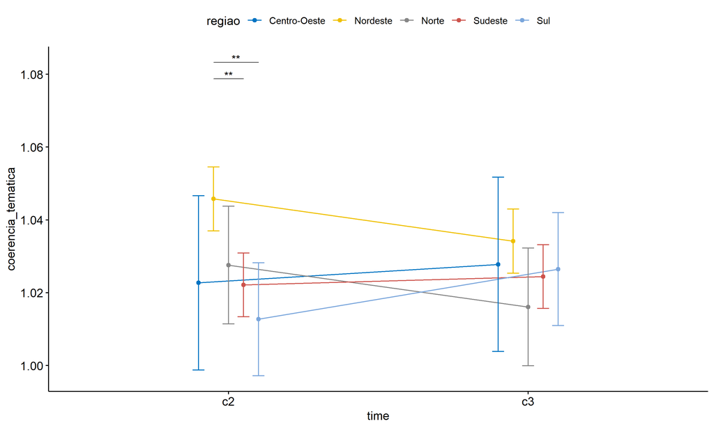

```r
pwc <- add_xy_position(pwc, x = "time", fun = "mean_se", dodge = 0.25)
pd <- position_dodge(width = 0.25)
ggline(emms, x = "time", y = "emmean", color = "regiao",
       palette = c("#0073C2FF","#EFC000FF","#868686FF","#CD534CFF","#7AA6DCFF"),
       position = pd, ylab = "coerencia_tematica") +
  geom_errorbar(aes(ymin = conf.low, ymax = conf.high, color = regiao),
                position = pd, width = 0.2) +
  stat_pvalue_manual(pwc, hide.ns = T, tip.length = F, linetype = 1)
```

```r
(pwc <- ldat %>% group_by(regiao) %>%
    emmeans_test(coerencia_tematica ~ time, detailed = T, p.adjust.method = "bonferroni"))
```

```
## # A tibble: 5 × 15
##   regiao    term  .y.   group1 group2 null.value estimate      se    df conf.low
## * <fct>     <chr> <chr> <chr>  <chr>       <dbl>    <dbl>   <dbl> <dbl>    <dbl>
## 1 Centro-O… time  coer… c2     c3              0 -0.00505 0.0173   8074 -3.89e-2
## 2 Nordeste  time  coer… c2     c3              0  0.0116  0.00635  8074 -8.36e-4
## 3 Norte     time  coer… c2     c3              0  0.0115  0.0117   8074 -1.13e-2
## 4 Sudeste   time  coer… c2     c3              0 -0.00230 0.00633  8074 -1.47e-2
## 5 Sul       time  coer… c2     c3              0 -0.0138  0.0112   8074 -3.57e-2
## # ℹ 5 more variables: conf.high <dbl>, statistic <dbl>, p <dbl>, p.adj <dbl>,
## #   p.adj.signif <chr>
```

| regiao | term | .y. | group1 | group2 | null.value | estimate | se | df | conf.low | conf.high | statistic | p | p.adj | p.adj.signif |
| --- | --- | --- | --- | --- | --- | --- | --- | --- | --- | --- | --- | --- | --- | --- |
| Centro-Oeste | time | coerencia_tematica | c2 | c3 | 0 | -0.005 | 0.017 | 8074 | -0.039 | 0.029 | -0.292 | 0.770 | 0.770 | ns |
| Nordeste | time | coerencia_tematica | c2 | c3 | 0 | 0.012 | 0.006 | 8074 | -0.001 | 0.024 | 1.829 | 0.068 | 0.068 | ns |
| Norte | time | coerencia_tematica | c2 | c3 | 0 | 0.011 | 0.012 | 8074 | -0.011 | 0.034 | 0.987 | 0.324 | 0.324 | ns |
| Sudeste | time | coerencia_tematica | c2 | c3 | 0 | -0.002 | 0.006 | 8074 | -0.015 | 0.010 | -0.363 | 0.717 | 0.717 | ns |
| Sul | time | coerencia_tematica | c2 | c3 | 0 | -0.014 | 0.011 | 8074 | -0.036 | 0.008 | -1.231 | 0.218 | 0.218 | ns |

```r
(emms <- get_emmeans(pwc))
```

```
## # A tibble: 10 × 8
##    regiao       time  emmean      se    df conf.low conf.high method
##    <fct>        <fct>  <dbl>   <dbl> <dbl>    <dbl>     <dbl> <chr>
##  1 Centro-Oeste c2      1.02 0.0122   8074    0.999      1.05 Emmeans test
##  2 Centro-Oeste c3      1.03 0.0122   8074    1.00       1.05 Emmeans test
##  3 Nordeste     c2      1.05 0.00449  8074    1.04       1.05 Emmeans test
##  4 Nordeste     c3      1.03 0.00449  8074    1.03       1.04 Emmeans test
##  5 Norte        c2      1.03 0.00824  8074    1.01       1.04 Emmeans test
##  6 Norte        c3      1.02 0.00824  8074    1.00       1.03 Emmeans test
##  7 Sudeste      c2      1.02 0.00448  8074    1.01       1.03 Emmeans test
##  8 Sudeste      c3      1.02 0.00448  8074    1.02       1.03 Emmeans test
##  9 Sul          c2      1.01 0.00791  8074    0.997      1.03 Emmeans test
## 10 Sul          c3      1.03 0.00791  8074    1.01       1.04 Emmeans test
```

| regiao | time | emmean | se | df | conf.low | conf.high | method |
| --- | --- | --- | --- | --- | --- | --- | --- |
| Centro-Oeste | c2 | 1.023 | 0.012 | 8074 | 0.999 | 1.047 | Emmeans test |
| Centro-Oeste | c3 | 1.028 | 0.012 | 8074 | 1.004 | 1.052 | Emmeans test |
| Nordeste | c2 | 1.046 | 0.004 | 8074 | 1.037 | 1.055 | Emmeans test |
| Nordeste | c3 | 1.034 | 0.004 | 8074 | 1.025 | 1.043 | Emmeans test |
| Norte | c2 | 1.028 | 0.008 | 8074 | 1.011 | 1.044 | Emmeans test |
| Norte | c3 | 1.016 | 0.008 | 8074 | 1.000 | 1.032 | Emmeans test |
| Sudeste | c2 | 1.022 | 0.004 | 8074 | 1.013 | 1.031 | Emmeans test |
| Sudeste | c3 | 1.024 | 0.004 | 8074 | 1.016 | 1.033 | Emmeans test |
| Sul | c2 | 1.013 | 0.008 | 8074 | 0.997 | 1.028 | Emmeans test |
| Sul | c3 | 1.026 | 0.008 | 8074 | 1.011 | 1.042 | Emmeans test |

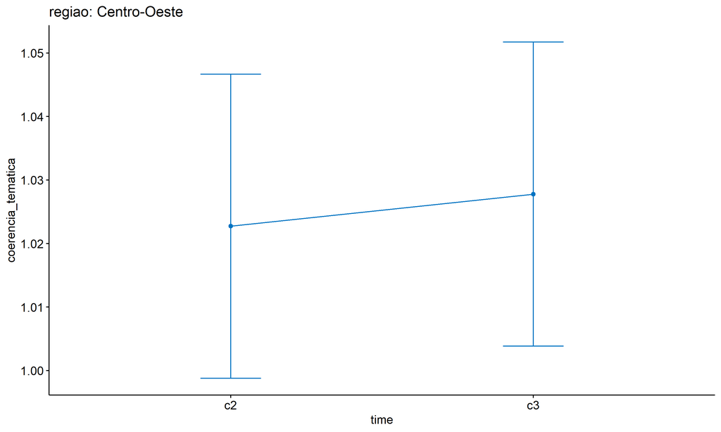

```r
emms.gg <- emms[which(emms$regiao == "Centro-Oeste"),]
if (nrow(emms.gg) > 0)
  ggline(emms.gg, x = "time", y = "emmean", color = "#0073C2FF", ylab = "coerencia_tematica") +
    geom_errorbar(aes(ymin = conf.low, ymax = conf.high),
                  width = 0.2, color = "#0073C2FF") +
    stat_pvalue_manual(
      add_xy_position(pwc[which(pwc$regiao == "Centro-Oeste"),],
                      x = "time", fun = "mean_se"),
      hide.ns = T, color = "#0073C2FF", tip.length = F) +
    labs(title = "regiao: Centro-Oeste")+
    theme(legend.text = element_blank())
```

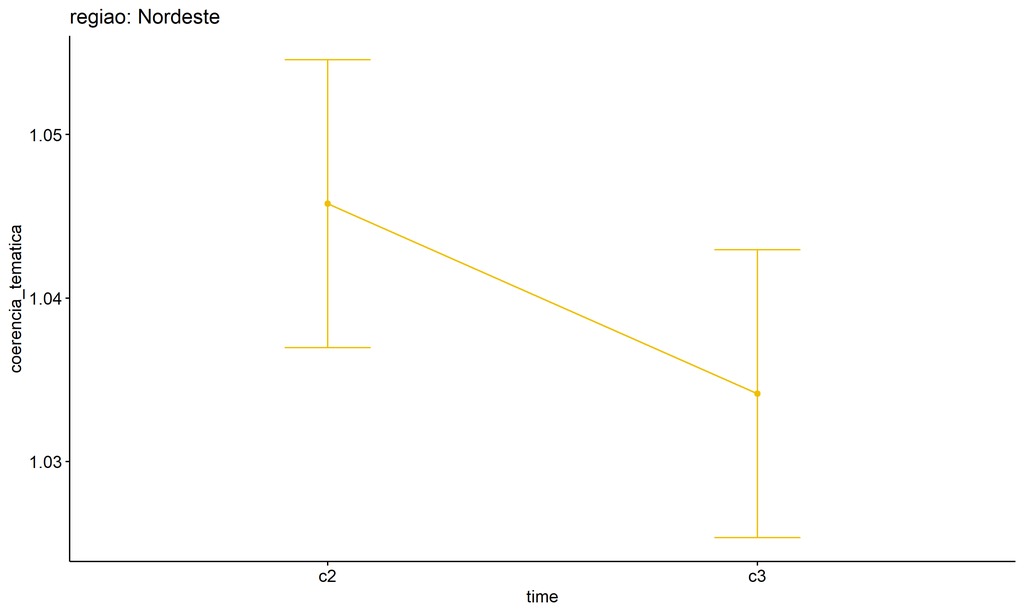

```r
emms.gg <- emms[which(emms$regiao == "Nordeste"),]
if (nrow(emms.gg) > 0)
  ggline(emms.gg, x = "time", y = "emmean", color = "#EFC000FF", ylab = "coerencia_tematica") +
    geom_errorbar(aes(ymin = conf.low, ymax = conf.high),
                  width = 0.2, color = "#EFC000FF") +
    stat_pvalue_manual(
      add_xy_position(pwc[which(pwc$regiao == "Nordeste"),],
                      x = "time", fun = "mean_se"),
      hide.ns = T, color = "#EFC000FF", tip.length = F) +
    labs(title = "regiao: Nordeste")+
    theme(legend.text = element_blank())
```

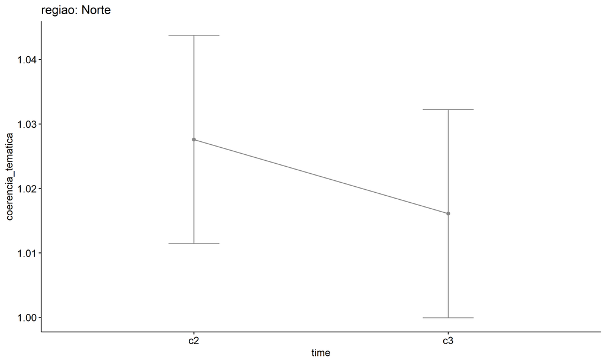

```r
emms.gg <- emms[which(emms$regiao == "Norte"),]
if (nrow(emms.gg) > 0)
  ggline(emms.gg, x = "time", y = "emmean", color = "#868686FF", ylab = "coerencia_tematica") +
    geom_errorbar(aes(ymin = conf.low, ymax = conf.high),
                  width = 0.2, color = "#868686FF") +
    stat_pvalue_manual(
      add_xy_position(pwc[which(pwc$regiao == "Norte"),],
                      x = "time", fun = "mean_se"),
      hide.ns = T, color = "#868686FF", tip.length = F) +
    labs(title = "regiao: Norte")+
    theme(legend.text = element_blank())
```

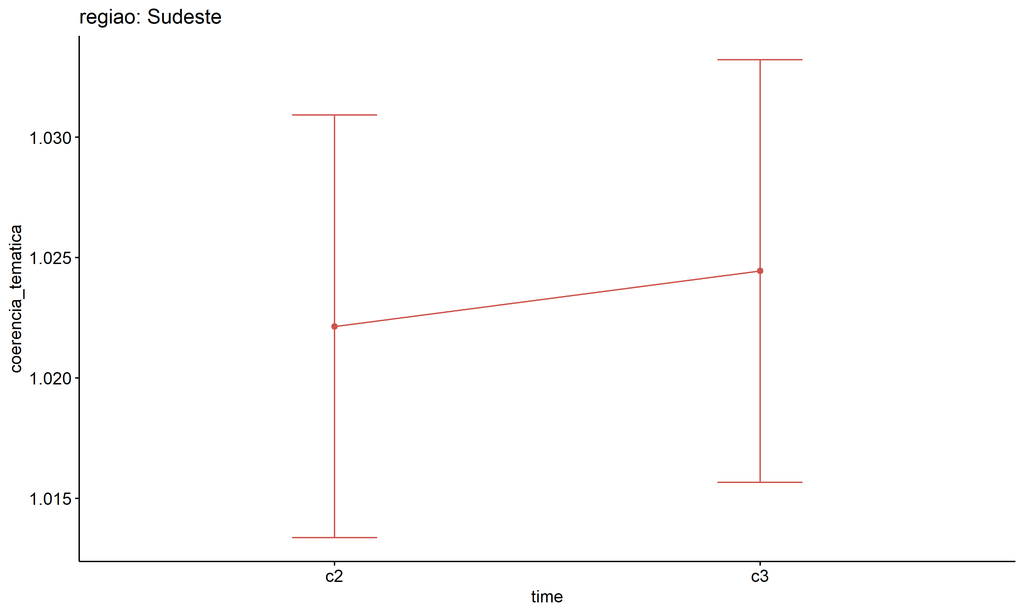

```r
emms.gg <- emms[which(emms$regiao == "Sudeste"),]
if (nrow(emms.gg) > 0)
  ggline(emms.gg, x = "time", y = "emmean", color = "#CD534CFF", ylab = "coerencia_tematica") +
    geom_errorbar(aes(ymin = conf.low, ymax = conf.high),
                  width = 0.2, color = "#CD534CFF") +
    stat_pvalue_manual(
      add_xy_position(pwc[which(pwc$regiao == "Sudeste"),],
                      x = "time", fun = "mean_se"),
      hide.ns = T, color = "#CD534CFF", tip.length = F) +
    labs(title = "regiao: Sudeste")+
    theme(legend.text = element_blank())
```

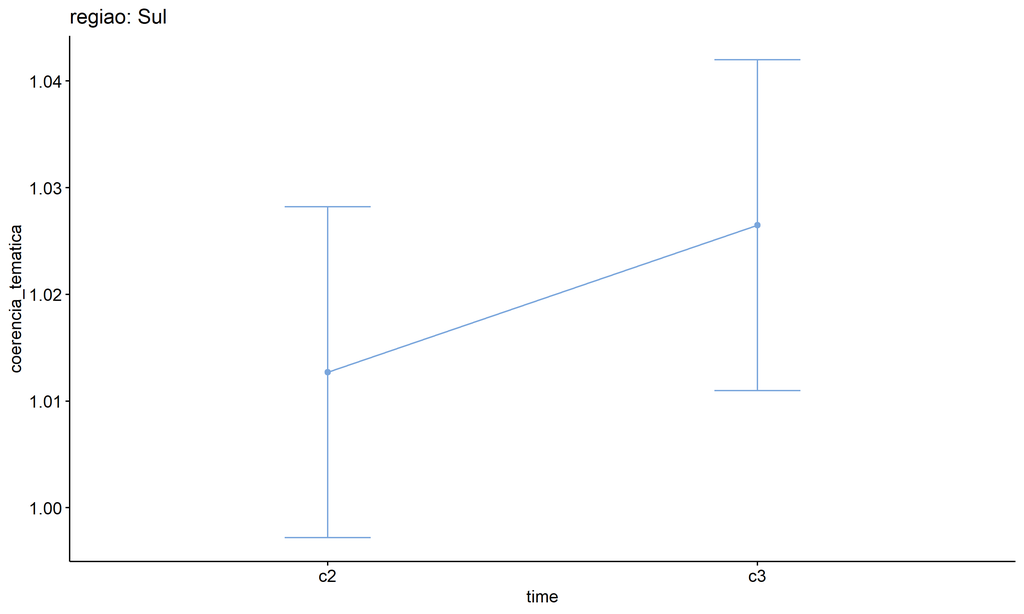

```r
emms.gg <- emms[which(emms$regiao == "Sul"),]
if (nrow(emms.gg) > 0)
  ggline(emms.gg, x = "time", y = "emmean", color = "#7AA6DCFF", ylab = "coerencia_tematica") +
    geom_errorbar(aes(ymin = conf.low, ymax = conf.high),
                  width = 0.2, color = "#7AA6DCFF") +
    stat_pvalue_manual(
      add_xy_position(pwc[which(pwc$regiao == "Sul"),],
                      x = "time", fun = "mean_se"),
      hide.ns = T, color = "#7AA6DCFF", tip.length = F) +
    labs(title = "regiao: Sul")+
    theme(legend.text = element_blank())
```

## PairWise Computation after removing non.normal data

```r
if (length(non.ids) > 0)
  (pwc2 <- ldat2 %>% group_by(time) %>%
     emmeans_test(coerencia_tematica ~ regiao, detailed = T, p.adjust.method = "bonferroni"))
```

```r
if (length(non.ids) > 0)
  (emms2 <- get_emmeans(pwc2))
```

```r
if (length(non.ids) > 0) {
  pwc2 <- add_xy_position(pwc2, x = "time", fun = "mean_se", dodge = 0.25)
  pd2 <- position_dodge(width = 0.25)

  ggline(emms2, x = "time", y = "emmean", color = "regiao",
         palette = c("#0073C2FF","#EFC000FF","#868686FF","#CD534CFF","#7AA6DCFF"),
         position = pd, ylab = "coerencia_tematica") +
    geom_errorbar(aes(ymin = conf.low, ymax = conf.high, color = regiao),
                position = pd, width = 0.2) +
    stat_pvalue_manual(pwc2, hide.ns = T, tip.length = F, linetype = 1)
}
```

```r
if (length(non.ids) > 0)
  (pwc2 <- ldat2 %>% group_by(regiao) %>%
     emmeans_test(coerencia_tematica ~ time, detailed = T, p.adjust.method = "bonferroni"))
```

```r
if (length(non.ids) > 0)
  (emms2 <- get_emmeans(pwc2))
```

```r
if (length(non.ids) > 0) {
  emms.gg <- emms2[which(emms2$regiao == "Centro-Oeste"),]
  if (nrow(emms.gg) > 0)
    ggline(emms.gg, x = "time", y = "emmean", color = "#0073C2FF", ylab = "coerencia_tematica") +
    geom_errorbar(aes(ymin = conf.low, ymax = conf.high),
                  width = 0.2, color = "#0073C2FF") +
    stat_pvalue_manual(
      add_xy_position(pwc[which(pwc$regiao == "Centro-Oeste"),],
                      x = "time", fun = "mean_se"),
      hide.ns = T, color = "#0073C2FF", tip.length = F) +
    labs(title = "regiao: Centro-Oeste") +
    theme(legend.text = element_blank())
}
```

```r
if (length(non.ids) > 0) {
  emms.gg <- emms2[which(emms2$regiao == "Nordeste"),]
  if (nrow(emms.gg) > 0)
    ggline(emms.gg, x = "time", y = "emmean", color = "#EFC000FF", ylab = "coerencia_tematica") +
    geom_errorbar(aes(ymin = conf.low, ymax = conf.high),
                  width = 0.2, color = "#EFC000FF") +
    stat_pvalue_manual(
      add_xy_position(pwc[which(pwc$regiao == "Nordeste"),],
                      x = "time", fun = "mean_se"),
      hide.ns = T, color = "#EFC000FF", tip.length = F) +
    labs(title = "regiao: Nordeste") +
    theme(legend.text = element_blank())
}
```

```r
if (length(non.ids) > 0) {
  emms.gg <- emms2[which(emms2$regiao == "Norte"),]
  if (nrow(emms.gg) > 0)
    ggline(emms.gg, x = "time", y = "emmean", color = "#868686FF", ylab = "coerencia_tematica") +
    geom_errorbar(aes(ymin = conf.low, ymax = conf.high),
                  width = 0.2, color = "#868686FF") +
    stat_pvalue_manual(
      add_xy_position(pwc[which(pwc$regiao == "Norte"),],
                      x = "time", fun = "mean_se"),
      hide.ns = T, color = "#868686FF", tip.length = F) +
    labs(title = "regiao: Norte") +
    theme(legend.text = element_blank())
}
```

```r
if (length(non.ids) > 0) {
  emms.gg <- emms2[which(emms2$regiao == "Sudeste"),]
  if (nrow(emms.gg) > 0)
    ggline(emms.gg, x = "time", y = "emmean", color = "#CD534CFF", ylab = "coerencia_tematica") +
    geom_errorbar(aes(ymin = conf.low, ymax = conf.high),
                  width = 0.2, color = "#CD534CFF") +
    stat_pvalue_manual(
      add_xy_position(pwc[which(pwc$regiao == "Sudeste"),],
                      x = "time", fun = "mean_se"),
      hide.ns = T, color = "#CD534CFF", tip.length = F) +
    labs(title = "regiao: Sudeste") +
    theme(legend.text = element_blank())
}
```

```r
if (length(non.ids) > 0) {
  emms.gg <- emms2[which(emms2$regiao == "Sul"),]
  if (nrow(emms.gg) > 0)
    ggline(emms.gg, x = "time", y = "emmean", color = "#7AA6DCFF", ylab = "coerencia_tematica") +
    geom_errorbar(aes(ymin = conf.low, ymax = conf.high),
                  width = 0.2, color = "#7AA6DCFF") +
    stat_pvalue_manual(
      add_xy_position(pwc[which(pwc$regiao == "Sul"),],
                      x = "time", fun = "mean_se"),
      hide.ns = T, color = "#7AA6DCFF", tip.length = F) +
    labs(title = "regiao: Sul") +
    theme(legend.text = element_blank())
}
```

# ANOVA: coerencia_tematica ~ time*porte + Error(id/time)

## Data Preparation

```r
data <- edat[,c("aluno_id","porte","ciclo","coerencia_tematica")]
data <- data[data$ciclo %in% c("Segundo Ciclo","Terceiro Ciclo"),]
data$ciclo <- factor(data$ciclo, c("Segundo Ciclo","Terceiro Ciclo"))
data <- unique(data)

wdat <- spread(data, ciclo, coerencia_tematica)
wdat <- wdat[complete.cases(wdat),]
colnames(wdat) <- c("id","porte","c2","c3")

ldat <- gather(wdat, key = time, value = coerencia_tematica, c2,c3) %>%
  convert_as_factor(id, time)
ldat <- remove_group_data(ldat, "coerencia_tematica", c("time", "porte"), n.limit = 30)
ldat$porte <- factor(ldat$porte, sort(unique(ldat$porte)))
```

### Check assumptions: Identifying Outliers

```r
outliers <- identify_outliers(group_by(ldat, time, porte), coerencia_tematica)
(outliers <- outliers[outliers$is.extreme == T,])
```

```
## # A tibble: 253 × 6
##    porte                    time  id    coerencia_tematica is.outlier is.extreme
##    <fct>                    <fct> <fct>              <dbl> <lgl>      <lgl>
##  1 Até 50 matrículas de es… c2    JKEv…                2   TRUE       TRUE
##  2 Entre 201 e 500 matrícu… c2    bBBG…                2   TRUE       TRUE
##  3 Entre 201 e 500 matrícu… c2    c8tC…                1.5 TRUE       TRUE
##  4 Entre 201 e 500 matrícu… c2    cFxw…                3   TRUE       TRUE
##  5 Entre 201 e 500 matrícu… c2    dzxW…                2   TRUE       TRUE
##  6 Entre 201 e 500 matrícu… c2    g2V9…                3   TRUE       TRUE
##  7 Entre 201 e 500 matrícu… c2    gcps…                1.5 TRUE       TRUE
##  8 Entre 201 e 500 matrícu… c2    gVuM…                2   TRUE       TRUE
##  9 Entre 201 e 500 matrícu… c2    GyXk…                1.5 TRUE       TRUE
## 10 Entre 201 e 500 matrícu… c2    hign…                2   TRUE       TRUE
## # ℹ 243 more rows
```

| porte | time | id | coerencia_tematica | is.outlier | is.extreme |
| --- | --- | --- | --- | --- | --- |
| Até 50 matrículas de escolarização | c2 | JKEvnqvCpv10PSAycuzr | 2.000 | TRUE | TRUE |
| Entre 201 e 500 matrículas de escolarização | c2 | bBBGsbvYBLgWujzEuOES | 2.000 | TRUE | TRUE |
| Entre 201 e 500 matrículas de escolarização | c2 | c8tCs09Zmla9HW6nXAba | 1.500 | TRUE | TRUE |
| Entre 201 e 500 matrículas de escolarização | c2 | cFxwLMwyCxWzWrkpwvkt | 3.000 | TRUE | TRUE |
| Entre 201 e 500 matrículas de escolarização | c2 | dzxWSwAxb1LbKLWq0f8W | 2.000 | TRUE | TRUE |
| Entre 201 e 500 matrículas de escolarização | c2 | g2V94DT753T4rGOFLnO9 | 3.000 | TRUE | TRUE |
| Entre 201 e 500 matrículas de escolarização | c2 | gcpsjKSQtozLkdeuPlAQ | 1.500 | TRUE | TRUE |
| Entre 201 e 500 matrículas de escolarização | c2 | gVuMjTLcSjwi8PtQcX3g | 2.000 | TRUE | TRUE |
| Entre 201 e 500 matrículas de escolarização | c2 | GyXkNYglZFaiWPdo2jHx | 1.500 | TRUE | TRUE |
| Entre 201 e 500 matrículas de escolarização | c2 | higntdffAusBUEJvytQY | 2.000 | TRUE | TRUE |
| Entre 201 e 500 matrículas de escolarização | c2 | hRksqP03n9bIhD3mMUSS | 1.500 | TRUE | TRUE |
| Entre 201 e 500 matrículas de escolarização | c2 | hV78K1w2Sy3NbDijChE1 | 2.000 | TRUE | TRUE |
| Entre 201 e 500 matrículas de escolarização | c2 | iGhiHBHlWPESJbq2D7PI | 2.000 | TRUE | TRUE |
| Entre 201 e 500 matrículas de escolarização | c2 | ILuG2m3xDKcwiThmAUW8 | 2.000 | TRUE | TRUE |
| Entre 201 e 500 matrículas de escolarização | c2 | ITPXRLN2xaGJzebM4a3K | 1.500 | TRUE | TRUE |
| Entre 201 e 500 matrículas de escolarização | c2 | iYlYrwjNTF4uR2dhpyxO | 1.500 | TRUE | TRUE |
| Entre 201 e 500 matrículas de escolarização | c2 | j29T3ZFdMcWxbBYVneR1 | 2.000 | TRUE | TRUE |
| Entre 201 e 500 matrículas de escolarização | c2 | j8nYm0EY03K9FNADOg7A | 2.000 | TRUE | TRUE |
| Entre 201 e 500 matrículas de escolarização | c2 | jibzqnofR0GRDwmmPk7Y | 2.000 | TRUE | TRUE |
| Entre 201 e 500 matrículas de escolarização | c2 | JxBy1XhCm6SIIhCxOv2f | 1.500 | TRUE | TRUE |
| Entre 201 e 500 matrículas de escolarização | c2 | kJIRWfRQpGpgJ9XydSAv | 2.000 | TRUE | TRUE |
| Entre 201 e 500 matrículas de escolarização | c2 | ks4CBM3zPHocVr9YlWDI | 1.500 | TRUE | TRUE |
| Entre 201 e 500 matrículas de escolarização | c2 | ksgo1zWUwzzFyFHwP56e | 1.500 | TRUE | TRUE |
| Entre 201 e 500 matrículas de escolarização | c2 | l14u3DL5ZLhsniQeUpJS | 1.500 | TRUE | TRUE |
| Entre 201 e 500 matrículas de escolarização | c2 | l23hjNOgy6nAwiy4LCWe | 2.000 | TRUE | TRUE |
| Entre 201 e 500 matrículas de escolarização | c2 | LjaXA0VBj0ofjYU1ASZY | 2.000 | TRUE | TRUE |
| Entre 201 e 500 matrículas de escolarização | c2 | llfmmeAJlptgMoFLELZa | 2.000 | TRUE | TRUE |
| Entre 201 e 500 matrículas de escolarização | c2 | lW5qykPQQcYd17PAfD2m | 1.500 | TRUE | TRUE |
| Entre 201 e 500 matrículas de escolarização | c2 | LzPHYYb0TblKO9PPMzWp | 2.000 | TRUE | TRUE |
| Entre 201 e 500 matrículas de escolarização | c2 | m0xj7CIrSEGFqXJYZr40 | 2.000 | TRUE | TRUE |

[output cut: 223 more lines]

### Check assumptions: Normality Test

```r
(normality.df <- normality.test.per.groups(ldat, "coerencia_tematica", c("time", "porte")))
```

```
##                   var           variable time
## 1  coerencia_tematica coerencia_tematica   c2
## 2  coerencia_tematica coerencia_tematica   c2
## 3  coerencia_tematica coerencia_tematica   c2
## 4  coerencia_tematica coerencia_tematica   c2
## 5  coerencia_tematica coerencia_tematica   c2
## 6  coerencia_tematica coerencia_tematica   c3
## 7  coerencia_tematica coerencia_tematica   c3
## 8  coerencia_tematica coerencia_tematica   c3
## 9  coerencia_tematica coerencia_tematica   c3
## 10 coerencia_tematica coerencia_tematica   c3
##                                           porte    n skewness kurtosis symmetry
## 1            Até 50 matrículas de escolarização   39 0.000000  0.00000 few data
## 2   Entre 201 e 500 matrículas de escolarização 1488 6.052486 42.00147       NO
## 3  Entre 501 e 1000 matrículas de escolarização 1922 6.874074 53.25111       NO
```

[output cut: 18 more lines]

| var | variable | time | porte | n | skewness | kurtosis | symmetry | statistic | method | p | p.signif | normality |
| --- | --- | --- | --- | --- | --- | --- | --- | --- | --- | --- | --- | --- |
| coerencia_tematica | coerencia_tematica | c2 | Até 50 matrículas de escolarização | 39 | 0.000 | 0.000 | few data | NA | NA | 1 | NA | NO |
| coerencia_tematica | coerencia_tematica | c2 | Entre 201 e 500 matrículas de escolarização | 1488 | 6.052 | 42.001 | NO | 1722.674 | D’Agostino | 0 | **** | - |
| coerencia_tematica | coerencia_tematica | c2 | Entre 501 e 1000 matrículas de escolarização | 1922 | 6.874 | 53.251 | NO | 2405.830 | D’Agostino | 0 | **** | - |
| coerencia_tematica | coerencia_tematica | c2 | Entre 51 e 200 matrículas de escolarização | 502 | 7.388 | 60.827 | NO | 699.035 | D’Agostino | 0 | **** | - |
| coerencia_tematica | coerencia_tematica | c2 | Mais de 1000 matrículas de escolarização | 91 | 0.000 | 0.000 | few data | NA | NA | 1 | NA | NO |
| coerencia_tematica | coerencia_tematica | c3 | Até 50 matrículas de escolarização | 39 | 0.000 | 0.000 | few data | NA | NA | 1 | NA | NO |
| coerencia_tematica | coerencia_tematica | c3 | Entre 201 e 500 matrículas de escolarização | 1488 | 6.351 | 44.210 | NO | 1774.039 | D’Agostino | 0 | **** | - |
| coerencia_tematica | coerencia_tematica | c3 | Entre 501 e 1000 matrículas de escolarização | 1922 | 7.358 | 58.770 | NO | 2507.328 | D’Agostino | 0 | **** | - |
| coerencia_tematica | coerencia_tematica | c3 | Entre 51 e 200 matrículas de escolarização | 502 | 6.008 | 39.387 | NO | 607.743 | D’Agostino | 0 | **** | - |
| coerencia_tematica | coerencia_tematica | c3 | Mais de 1000 matrículas de escolarização | 91 | 0.000 | 0.000 | few data | NA | NA | 1 | NA | NO |

```r
(non.ids <- unique(do.call(
  c, lapply(which(normality.df$normality == 'NO'), FUN = function(i) {
  idx = which(ldat$time == normality.df$time[i] &
                ldat$porte == normality.df$porte[i])
  getNonNormal(ldat$"coerencia_tematica"[idx], ldat$id[idx])
}))))
```

```r
if (length(non.ids) > 0)
  ldat2 <- ldat[!ldat$id %in% non.ids,]
```

### Summary Statistics

```r
(sdat <- ldat %>% group_by(time, porte) %>%
   get_summary_stats(coerencia_tematica, type = "mean_sd"))
```

```
## # A tibble: 10 × 6
##    porte                                        time  variable     n  mean    sd
##    <fct>                                        <fct> <fct>    <dbl> <dbl> <dbl>
##  1 Até 50 matrículas de escolarização           c2    coerenc…    39  1.03 0.16
##  2 Entre 201 e 500 matrículas de escolarização  c2    coerenc…  1488  1.04 0.191
##  3 Entre 501 e 1000 matrículas de escolarização c2    coerenc…  1922  1.03 0.159
##  4 Entre 51 e 200 matrículas de escolarização   c2    coerenc…   502  1.03 0.186
##  5 Mais de 1000 matrículas de escolarização     c2    coerenc…    91  1.00 0.052
##  6 Até 50 matrículas de escolarização           c3    coerenc…    39  1.03 0.16
##  7 Entre 201 e 500 matrículas de escolarização  c3    coerenc…  1488  1.03 0.183
##  8 Entre 501 e 1000 matrículas de escolarização c3    coerenc…  1922  1.02 0.153
##  9 Entre 51 e 200 matrículas de escolarização   c3    coerenc…   502  1.03 0.189
## 10 Mais de 1000 matrículas de escolarização     c3    coerenc…    91  1.04 0.206
```

| porte | time | variable | n | mean | sd |
| --- | --- | --- | --- | --- | --- |
| Até 50 matrículas de escolarização | c2 | coerencia_tematica | 39 | 1.026 | 0.160 |
| Entre 201 e 500 matrículas de escolarização | c2 | coerencia_tematica | 1488 | 1.037 | 0.191 |
| Entre 501 e 1000 matrículas de escolarização | c2 | coerencia_tematica | 1922 | 1.027 | 0.159 |
| Entre 51 e 200 matrículas de escolarização | c2 | coerencia_tematica | 502 | 1.029 | 0.186 |
| Mais de 1000 matrículas de escolarização | c2 | coerencia_tematica | 91 | 1.005 | 0.052 |
| Até 50 matrículas de escolarização | c3 | coerencia_tematica | 39 | 1.026 | 0.160 |
| Entre 201 e 500 matrículas de escolarização | c3 | coerencia_tematica | 1488 | 1.031 | 0.183 |
| Entre 501 e 1000 matrículas de escolarização | c3 | coerencia_tematica | 1922 | 1.022 | 0.153 |
| Entre 51 e 200 matrículas de escolarização | c3 | coerencia_tematica | 502 | 1.034 | 0.189 |
| Mais de 1000 matrículas de escolarização | c3 | coerencia_tematica | 91 | 1.044 | 0.206 |

```r
if (length(non.ids) > 0)
  (sdat <- ldat2 %>% group_by(time, porte) %>%
      get_summary_stats(coerencia_tematica, type = "mean_sd"))
```

| porte | time | variable | n | mean | sd |
| --- | --- | --- | --- | --- | --- |
| Até 50 matrículas de escolarização | c2 | coerencia_tematica | 39 | 1.026 | 0.160 |
| Entre 201 e 500 matrículas de escolarização | c2 | coerencia_tematica | 1488 | 1.037 | 0.191 |
| Entre 501 e 1000 matrículas de escolarização | c2 | coerencia_tematica | 1922 | 1.027 | 0.159 |
| Entre 51 e 200 matrículas de escolarização | c2 | coerencia_tematica | 502 | 1.029 | 0.186 |
| Mais de 1000 matrículas de escolarização | c2 | coerencia_tematica | 91 | 1.005 | 0.052 |
| Até 50 matrículas de escolarização | c3 | coerencia_tematica | 39 | 1.026 | 0.160 |
| Entre 201 e 500 matrículas de escolarização | c3 | coerencia_tematica | 1488 | 1.031 | 0.183 |
| Entre 501 e 1000 matrículas de escolarização | c3 | coerencia_tematica | 1922 | 1.022 | 0.153 |
| Entre 51 e 200 matrículas de escolarização | c3 | coerencia_tematica | 502 | 1.034 | 0.189 |
| Mais de 1000 matrículas de escolarização | c3 | coerencia_tematica | 91 | 1.044 | 0.206 |

## ANOVA Computation

```r
(res.aov <- anova_test(ldat, dv = coerencia_tematica, wid = id, between = porte, within = time))
```

```
## ANOVA Table (type III tests)
##
##       Effect DFn  DFd     F     p p<.05      ges
## 1      porte   4 4037 1.277 0.277       7.12e-04
## 2       time   1 4037 0.537 0.464       5.81e-05
## 3 porte:time   4 4037 0.985 0.414       4.26e-04
```

## ANOVA Computation after removing non.normal data

```r
if (length(non.ids) > 0)
  (res.aov2 <- anova_test(ldat2, dv = coerencia_tematica, wid = id, between = porte , within = time))
```

## PairWise Computation

```r
(pwc <- ldat %>% group_by(time) %>%
   emmeans_test(coerencia_tematica ~ porte, detailed = T, p.adjust.method = "bonferroni"))
```

```
## # A tibble: 20 × 15
##    time  term  .y.      group1 group2 null.value estimate      se    df conf.low
##  * <fct> <chr> <chr>    <chr>  <chr>       <dbl>    <dbl>   <dbl> <dbl>    <dbl>
##  1 c2    porte coerenc… Até 5… Entre…          0 -1.13e-2 0.0279   8074 -0.0660
##  2 c2    porte coerenc… Até 5… Entre…          0 -9.55e-4 0.0278   8074 -0.0555
##  3 c2    porte coerenc… Até 5… Entre…          0 -3.24e-3 0.0286   8074 -0.0593
##  4 c2    porte coerenc… Até 5… Mais …          0  2.01e-2 0.0329   8074 -0.0444
##  5 c2    porte coerenc… Entre… Entre…          0  1.04e-2 0.00594  8074 -0.00127
##  6 c2    porte coerenc… Entre… Entre…          0  8.08e-3 0.00888  8074 -0.00932
##  7 c2    porte coerenc… Entre… Mais …          0  3.15e-2 0.0186   8074 -0.00494
##  8 c2    porte coerenc… Entre… Entre…          0 -2.29e-3 0.00862  8074 -0.0192
##  9 c2    porte coerenc… Entre… Mais …          0  2.11e-2 0.0185   8074 -0.0151
## 10 c2    porte coerenc… Entre… Mais …          0  2.34e-2 0.0196   8074 -0.0150
## 11 c3    porte coerenc… Até 5… Entre…          0 -5.61e-3 0.0279   8074 -0.0603
## 12 c3    porte coerenc… Até 5… Entre…          0  3.53e-3 0.0278   8074 -0.0510
## 13 c3    porte coerenc… Até 5… Entre…          0 -8.22e-3 0.0286   8074 -0.0643
## 14 c3    porte coerenc… Até 5… Mais …          0 -1.83e-2 0.0329   8074 -0.0828
## 15 c3    porte coerenc… Entre… Entre…          0  9.14e-3 0.00594  8074 -0.00250
## 16 c3    porte coerenc… Entre… Entre…          0 -2.61e-3 0.00888  8074 -0.0200
## 17 c3    porte coerenc… Entre… Mais …          0 -1.27e-2 0.0186   8074 -0.0491
## 18 c3    porte coerenc… Entre… Entre…          0 -1.18e-2 0.00862  8074 -0.0287
## 19 c3    porte coerenc… Entre… Mais …          0 -2.18e-2 0.0185   8074 -0.0580
## 20 c3    porte coerenc… Entre… Mais …          0 -1.01e-2 0.0196   8074 -0.0485
## # ℹ 5 more variables: conf.high <dbl>, statistic <dbl>, p <dbl>, p.adj <dbl>,
## #   p.adj.signif <chr>
```

| time | term | .y. | group1 | group2 | null.value | estimate | se | df | conf.low | conf.high | statistic | p | p.adj | p.adj.signif |
| --- | --- | --- | --- | --- | --- | --- | --- | --- | --- | --- | --- | --- | --- | --- |
| c2 | porte | coerencia_tematica | Até 50 matrículas de escolarização | Entre 201 e 500 matrículas de escolarização | 0 | -0.011 | 0.028 | 8074 | -0.066 | 0.043 | -0.406 | 0.685 | 1.000 | ns |
| c2 | porte | coerencia_tematica | Até 50 matrículas de escolarização | Entre 501 e 1000 matrículas de escolarização | 0 | -0.001 | 0.028 | 8074 | -0.055 | 0.054 | -0.034 | 0.973 | 1.000 | ns |
| c2 | porte | coerencia_tematica | Até 50 matrículas de escolarização | Entre 51 e 200 matrículas de escolarização | 0 | -0.003 | 0.029 | 8074 | -0.059 | 0.053 | -0.113 | 0.910 | 1.000 | ns |
| c2 | porte | coerencia_tematica | Até 50 matrículas de escolarização | Mais de 1000 matrículas de escolarização | 0 | 0.020 | 0.033 | 8074 | -0.044 | 0.085 | 0.612 | 0.541 | 1.000 | ns |
| c2 | porte | coerencia_tematica | Entre 201 e 500 matrículas de escolarização | Entre 501 e 1000 matrículas de escolarização | 0 | 0.010 | 0.006 | 8074 | -0.001 | 0.022 | 1.746 | 0.081 | 0.809 | ns |
| c2 | porte | coerencia_tematica | Entre 201 e 500 matrículas de escolarização | Entre 51 e 200 matrículas de escolarização | 0 | 0.008 | 0.009 | 8074 | -0.009 | 0.025 | 0.910 | 0.363 | 1.000 | ns |
| c2 | porte | coerencia_tematica | Entre 201 e 500 matrículas de escolarização | Mais de 1000 matrículas de escolarização | 0 | 0.031 | 0.019 | 8074 | -0.005 | 0.068 | 1.694 | 0.090 | 0.902 | ns |
| c2 | porte | coerencia_tematica | Entre 501 e 1000 matrículas de escolarização | Entre 51 e 200 matrículas de escolarização | 0 | -0.002 | 0.009 | 8074 | -0.019 | 0.015 | -0.266 | 0.791 | 1.000 | ns |
| c2 | porte | coerencia_tematica | Entre 501 e 1000 matrículas de escolarização | Mais de 1000 matrículas de escolarização | 0 | 0.021 | 0.018 | 8074 | -0.015 | 0.057 | 1.144 | 0.253 | 1.000 | ns |
| c2 | porte | coerencia_tematica | Entre 51 e 200 matrículas de escolarização | Mais de 1000 matrículas de escolarização | 0 | 0.023 | 0.020 | 8074 | -0.015 | 0.062 | 1.194 | 0.233 | 1.000 | ns |
| c3 | porte | coerencia_tematica | Até 50 matrículas de escolarização | Entre 201 e 500 matrículas de escolarização | 0 | -0.006 | 0.028 | 8074 | -0.060 | 0.049 | -0.201 | 0.841 | 1.000 | ns |
| c3 | porte | coerencia_tematica | Até 50 matrículas de escolarização | Entre 501 e 1000 matrículas de escolarização | 0 | 0.004 | 0.028 | 8074 | -0.051 | 0.058 | 0.127 | 0.899 | 1.000 | ns |
| c3 | porte | coerencia_tematica | Até 50 matrículas de escolarização | Entre 51 e 200 matrículas de escolarização | 0 | -0.008 | 0.029 | 8074 | -0.064 | 0.048 | -0.288 | 0.774 | 1.000 | ns |
| c3 | porte | coerencia_tematica | Até 50 matrículas de escolarização | Mais de 1000 matrículas de escolarização | 0 | -0.018 | 0.033 | 8074 | -0.083 | 0.046 | -0.556 | 0.578 | 1.000 | ns |
| c3 | porte | coerencia_tematica | Entre 201 e 500 matrículas de escolarização | Entre 501 e 1000 matrículas de escolarização | 0 | 0.009 | 0.006 | 8074 | -0.003 | 0.021 | 1.539 | 0.124 | 1.000 | ns |
| c3 | porte | coerencia_tematica | Entre 201 e 500 matrículas de escolarização | Entre 51 e 200 matrículas de escolarização | 0 | -0.003 | 0.009 | 8074 | -0.020 | 0.015 | -0.295 | 0.768 | 1.000 | ns |
| c3 | porte | coerencia_tematica | Entre 201 e 500 matrículas de escolarização | Mais de 1000 matrículas de escolarização | 0 | -0.013 | 0.019 | 8074 | -0.049 | 0.024 | -0.684 | 0.494 | 1.000 | ns |
| c3 | porte | coerencia_tematica | Entre 501 e 1000 matrículas de escolarização | Entre 51 e 200 matrículas de escolarização | 0 | -0.012 | 0.009 | 8074 | -0.029 | 0.005 | -1.363 | 0.173 | 1.000 | ns |
| c3 | porte | coerencia_tematica | Entre 501 e 1000 matrículas de escolarização | Mais de 1000 matrículas de escolarização | 0 | -0.022 | 0.018 | 8074 | -0.058 | 0.014 | -1.184 | 0.236 | 1.000 | ns |
| c3 | porte | coerencia_tematica | Entre 51 e 200 matrículas de escolarização | Mais de 1000 matrículas de escolarização | 0 | -0.010 | 0.020 | 8074 | -0.049 | 0.028 | -0.515 | 0.607 | 1.000 | ns |

```r
(emms <- get_emmeans(pwc))
```

```
## # A tibble: 10 × 8
##    time  porte                    emmean      se    df conf.low conf.high method
##    <fct> <fct>                     <dbl>   <dbl> <dbl>    <dbl>     <dbl> <chr>
##  1 c2    Até 50 matrículas de es…   1.03 0.0275   8074    0.972      1.08 Emmea…
##  2 c2    Entre 201 e 500 matrícu…   1.04 0.00446  8074    1.03       1.05 Emmea…
##  3 c2    Entre 501 e 1000 matríc…   1.03 0.00392  8074    1.02       1.03 Emmea…
##  4 c2    Entre 51 e 200 matrícul…   1.03 0.00768  8074    1.01       1.04 Emmea…
##  5 c2    Mais de 1000 matrículas…   1.01 0.0180   8074    0.970      1.04 Emmea…
##  6 c3    Até 50 matrículas de es…   1.03 0.0275   8074    0.972      1.08 Emmea…
##  7 c3    Entre 201 e 500 matrícu…   1.03 0.00446  8074    1.02       1.04 Emmea…
##  8 c3    Entre 501 e 1000 matríc…   1.02 0.00392  8074    1.01       1.03 Emmea…
##  9 c3    Entre 51 e 200 matrícul…   1.03 0.00768  8074    1.02       1.05 Emmea…
## 10 c3    Mais de 1000 matrículas…   1.04 0.0180   8074    1.01       1.08 Emmea…
```

| time | porte | emmean | se | df | conf.low | conf.high | method |
| --- | --- | --- | --- | --- | --- | --- | --- |
| c2 | Até 50 matrículas de escolarização | 1.026 | 0.028 | 8074 | 0.972 | 1.080 | Emmeans test |
| c2 | Entre 201 e 500 matrículas de escolarização | 1.037 | 0.004 | 8074 | 1.028 | 1.046 | Emmeans test |
| c2 | Entre 501 e 1000 matrículas de escolarização | 1.027 | 0.004 | 8074 | 1.019 | 1.034 | Emmeans test |
| c2 | Entre 51 e 200 matrículas de escolarização | 1.029 | 0.008 | 8074 | 1.014 | 1.044 | Emmeans test |
| c2 | Mais de 1000 matrículas de escolarização | 1.005 | 0.018 | 8074 | 0.970 | 1.041 | Emmeans test |
| c3 | Até 50 matrículas de escolarização | 1.026 | 0.028 | 8074 | 0.972 | 1.080 | Emmeans test |
| c3 | Entre 201 e 500 matrículas de escolarização | 1.031 | 0.004 | 8074 | 1.023 | 1.040 | Emmeans test |
| c3 | Entre 501 e 1000 matrículas de escolarização | 1.022 | 0.004 | 8074 | 1.014 | 1.030 | Emmeans test |
| c3 | Entre 51 e 200 matrículas de escolarização | 1.034 | 0.008 | 8074 | 1.019 | 1.049 | Emmeans test |
| c3 | Mais de 1000 matrículas de escolarização | 1.044 | 0.018 | 8074 | 1.009 | 1.079 | Emmeans test |

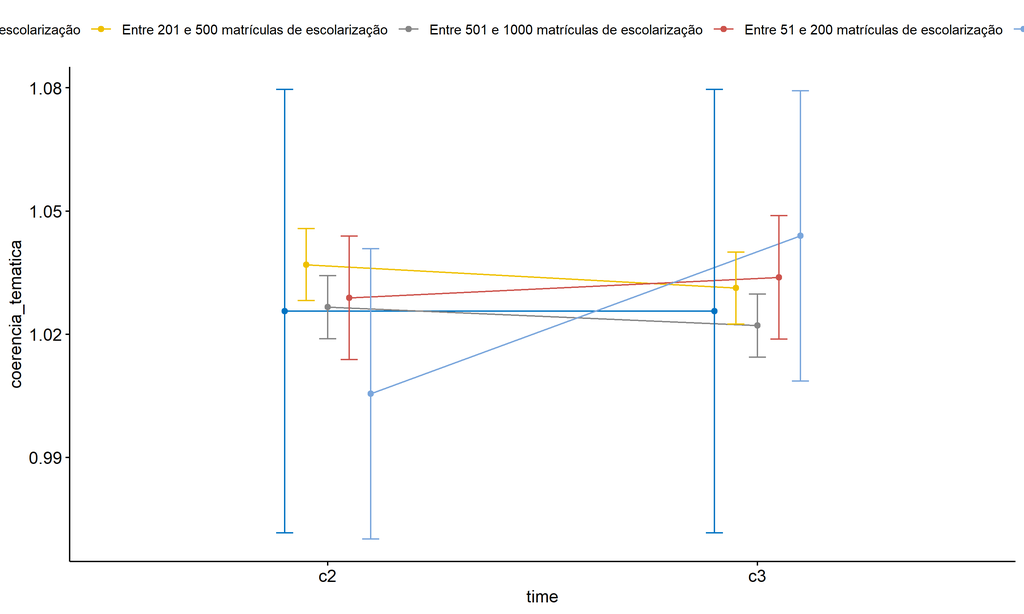

```r
pwc <- add_xy_position(pwc, x = "time", fun = "mean_se", dodge = 0.25)
pd <- position_dodge(width = 0.25)
ggline(emms, x = "time", y = "emmean", color = "porte",
       palette = c("#0073C2FF","#EFC000FF","#868686FF","#CD534CFF","#7AA6DCFF"),
       position = pd, ylab = "coerencia_tematica") +
  geom_errorbar(aes(ymin = conf.low, ymax = conf.high, color = porte),
                position = pd, width = 0.2) +
  stat_pvalue_manual(pwc, hide.ns = T, tip.length = F, linetype = 1)
```

```r
(pwc <- ldat %>% group_by(porte) %>%
    emmeans_test(coerencia_tematica ~ time, detailed = T, p.adjust.method = "bonferroni"))
```

```
## # A tibble: 5 × 15
##   porte    term  .y.   group1 group2 null.value  estimate      se    df conf.low
## * <fct>    <chr> <chr> <chr>  <chr>       <dbl>     <dbl>   <dbl> <dbl>    <dbl>
## 1 Até 50 … time  coer… c2     c3              0 -2.45e-16 0.0389   8074 -0.0763
## 2 Entre 2… time  coer… c2     c3              0  5.71e- 3 0.00631  8074 -0.00665
## 3 Entre 5… time  coer… c2     c3              0  4.48e- 3 0.00555  8074 -0.00639
## 4 Entre 5… time  coer… c2     c3              0 -4.98e- 3 0.0109   8074 -0.0263
## 5 Mais de… time  coer… c2     c3              0 -3.85e- 2 0.0255   8074 -0.0884
## # ℹ 5 more variables: conf.high <dbl>, statistic <dbl>, p <dbl>, p.adj <dbl>,
## #   p.adj.signif <chr>
```

| porte | term | .y. | group1 | group2 | null.value | estimate | se | df | conf.low | conf.high | statistic | p | p.adj | p.adj.signif |
| --- | --- | --- | --- | --- | --- | --- | --- | --- | --- | --- | --- | --- | --- | --- |
| Até 50 matrículas de escolarização | time | coerencia_tematica | c2 | c3 | 0 | 0.000 | 0.039 | 8074 | -0.076 | 0.076 | 0.000 | 1.000 | 1.000 | ns |
| Entre 201 e 500 matrículas de escolarização | time | coerencia_tematica | c2 | c3 | 0 | 0.006 | 0.006 | 8074 | -0.007 | 0.018 | 0.906 | 0.365 | 0.365 | ns |
| Entre 501 e 1000 matrículas de escolarização | time | coerencia_tematica | c2 | c3 | 0 | 0.004 | 0.006 | 8074 | -0.006 | 0.015 | 0.808 | 0.419 | 0.419 | ns |
| Entre 51 e 200 matrículas de escolarização | time | coerencia_tematica | c2 | c3 | 0 | -0.005 | 0.011 | 8074 | -0.026 | 0.016 | -0.459 | 0.646 | 0.646 | ns |
| Mais de 1000 matrículas de escolarização | time | coerencia_tematica | c2 | c3 | 0 | -0.038 | 0.025 | 8074 | -0.088 | 0.012 | -1.509 | 0.131 | 0.131 | ns |

```r
(emms <- get_emmeans(pwc))
```

```
## # A tibble: 10 × 8
##    porte                    time  emmean      se    df conf.low conf.high method
##    <fct>                    <fct>  <dbl>   <dbl> <dbl>    <dbl>     <dbl> <chr>
##  1 Até 50 matrículas de es… c2      1.03 0.0275   8074    0.972      1.08 Emmea…
##  2 Até 50 matrículas de es… c3      1.03 0.0275   8074    0.972      1.08 Emmea…
##  3 Entre 201 e 500 matrícu… c2      1.04 0.00446  8074    1.03       1.05 Emmea…
##  4 Entre 201 e 500 matrícu… c3      1.03 0.00446  8074    1.02       1.04 Emmea…
##  5 Entre 501 e 1000 matríc… c2      1.03 0.00392  8074    1.02       1.03 Emmea…
##  6 Entre 501 e 1000 matríc… c3      1.02 0.00392  8074    1.01       1.03 Emmea…
##  7 Entre 51 e 200 matrícul… c2      1.03 0.00768  8074    1.01       1.04 Emmea…
##  8 Entre 51 e 200 matrícul… c3      1.03 0.00768  8074    1.02       1.05 Emmea…
##  9 Mais de 1000 matrículas… c2      1.01 0.0180   8074    0.970      1.04 Emmea…
## 10 Mais de 1000 matrículas… c3      1.04 0.0180   8074    1.01       1.08 Emmea…
```

| porte | time | emmean | se | df | conf.low | conf.high | method |
| --- | --- | --- | --- | --- | --- | --- | --- |
| Até 50 matrículas de escolarização | c2 | 1.026 | 0.028 | 8074 | 0.972 | 1.080 | Emmeans test |
| Até 50 matrículas de escolarização | c3 | 1.026 | 0.028 | 8074 | 0.972 | 1.080 | Emmeans test |
| Entre 201 e 500 matrículas de escolarização | c2 | 1.037 | 0.004 | 8074 | 1.028 | 1.046 | Emmeans test |
| Entre 201 e 500 matrículas de escolarização | c3 | 1.031 | 0.004 | 8074 | 1.023 | 1.040 | Emmeans test |
| Entre 501 e 1000 matrículas de escolarização | c2 | 1.027 | 0.004 | 8074 | 1.019 | 1.034 | Emmeans test |
| Entre 501 e 1000 matrículas de escolarização | c3 | 1.022 | 0.004 | 8074 | 1.014 | 1.030 | Emmeans test |
| Entre 51 e 200 matrículas de escolarização | c2 | 1.029 | 0.008 | 8074 | 1.014 | 1.044 | Emmeans test |
| Entre 51 e 200 matrículas de escolarização | c3 | 1.034 | 0.008 | 8074 | 1.019 | 1.049 | Emmeans test |
| Mais de 1000 matrículas de escolarização | c2 | 1.005 | 0.018 | 8074 | 0.970 | 1.041 | Emmeans test |
| Mais de 1000 matrículas de escolarização | c3 | 1.044 | 0.018 | 8074 | 1.009 | 1.079 | Emmeans test |

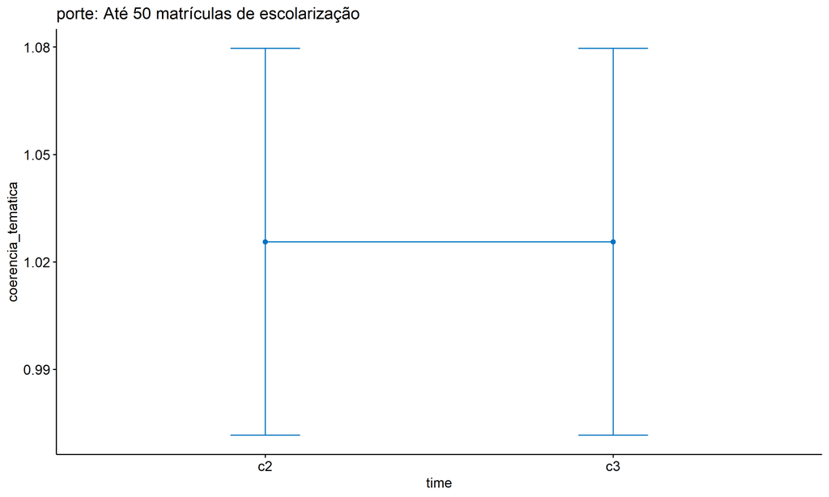

```r
emms.gg <- emms[which(emms$porte == "Até 50 matrículas de escolarização"),]
if (nrow(emms.gg) > 0)
  ggline(emms.gg, x = "time", y = "emmean", color = "#0073C2FF", ylab = "coerencia_tematica") +
    geom_errorbar(aes(ymin = conf.low, ymax = conf.high),
                  width = 0.2, color = "#0073C2FF") +
    stat_pvalue_manual(
      add_xy_position(pwc[which(pwc$porte == "Até 50 matrículas de escolarização"),],
                      x = "time", fun = "mean_se"),
      hide.ns = T, color = "#0073C2FF", tip.length = F) +
    labs(title = "porte: Até 50 matrículas de escolarização")+
    theme(legend.text = element_blank())
```

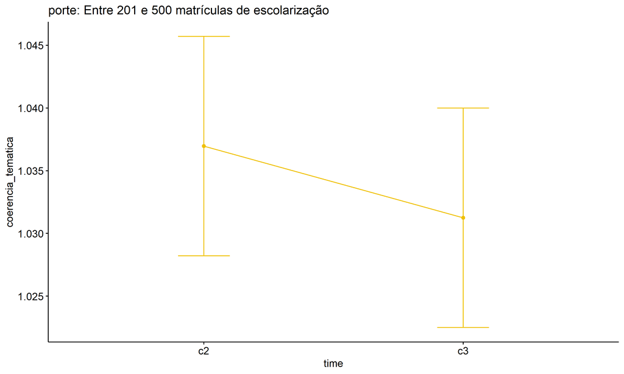

```r
emms.gg <- emms[which(emms$porte == "Entre 201 e 500 matrículas de escolarização"),]
if (nrow(emms.gg) > 0)
  ggline(emms.gg, x = "time", y = "emmean", color = "#EFC000FF", ylab = "coerencia_tematica") +
    geom_errorbar(aes(ymin = conf.low, ymax = conf.high),
                  width = 0.2, color = "#EFC000FF") +
    stat_pvalue_manual(
      add_xy_position(pwc[which(pwc$porte == "Entre 201 e 500 matrículas de escolarização"),],
                      x = "time", fun = "mean_se"),
      hide.ns = T, color = "#EFC000FF", tip.length = F) +
    labs(title = "porte: Entre 201 e 500 matrículas de escolarização")+
    theme(legend.text = element_blank())
```

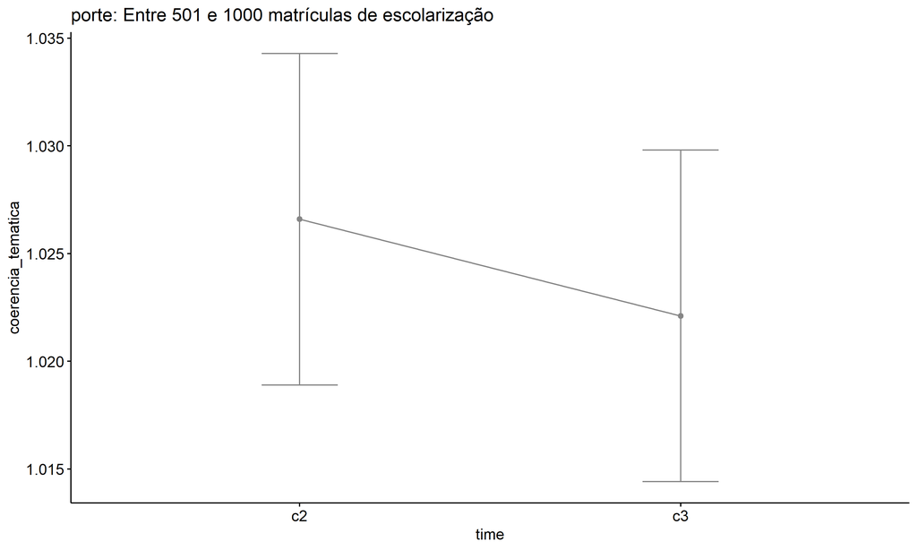

```r
emms.gg <- emms[which(emms$porte == "Entre 501 e 1000 matrículas de escolarização"),]
if (nrow(emms.gg) > 0)
  ggline(emms.gg, x = "time", y = "emmean", color = "#868686FF", ylab = "coerencia_tematica") +
    geom_errorbar(aes(ymin = conf.low, ymax = conf.high),
                  width = 0.2, color = "#868686FF") +
    stat_pvalue_manual(
      add_xy_position(pwc[which(pwc$porte == "Entre 501 e 1000 matrículas de escolarização"),],
                      x = "time", fun = "mean_se"),
      hide.ns = T, color = "#868686FF", tip.length = F) +
    labs(title = "porte: Entre 501 e 1000 matrículas de escolarização")+
    theme(legend.text = element_blank())
```

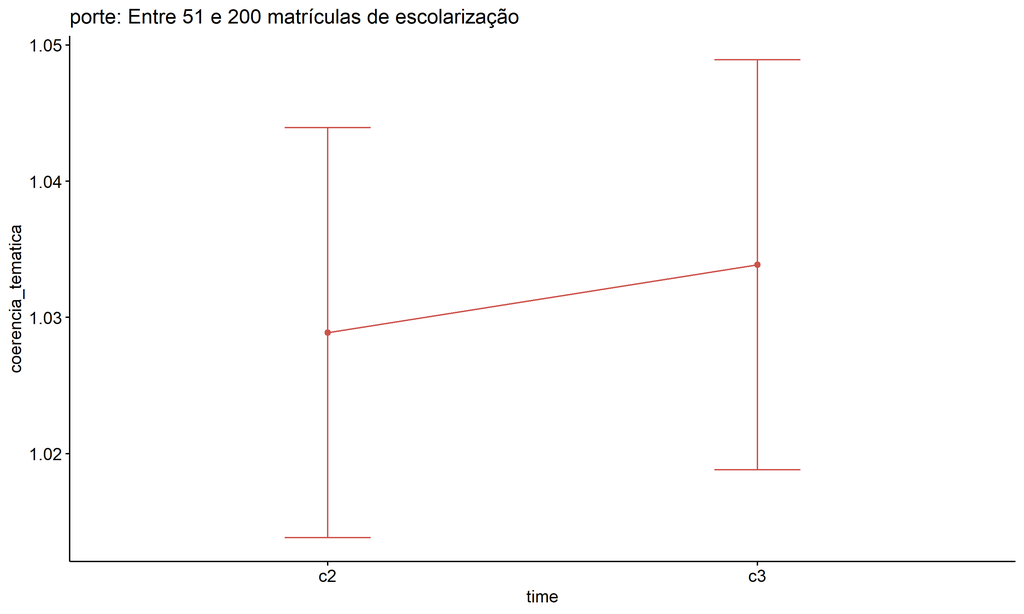

```r
emms.gg <- emms[which(emms$porte == "Entre 51 e 200 matrículas de escolarização"),]
if (nrow(emms.gg) > 0)
  ggline(emms.gg, x = "time", y = "emmean", color = "#CD534CFF", ylab = "coerencia_tematica") +
    geom_errorbar(aes(ymin = conf.low, ymax = conf.high),
                  width = 0.2, color = "#CD534CFF") +
    stat_pvalue_manual(
      add_xy_position(pwc[which(pwc$porte == "Entre 51 e 200 matrículas de escolarização"),],
                      x = "time", fun = "mean_se"),
      hide.ns = T, color = "#CD534CFF", tip.length = F) +
    labs(title = "porte: Entre 51 e 200 matrículas de escolarização")+
    theme(legend.text = element_blank())
```

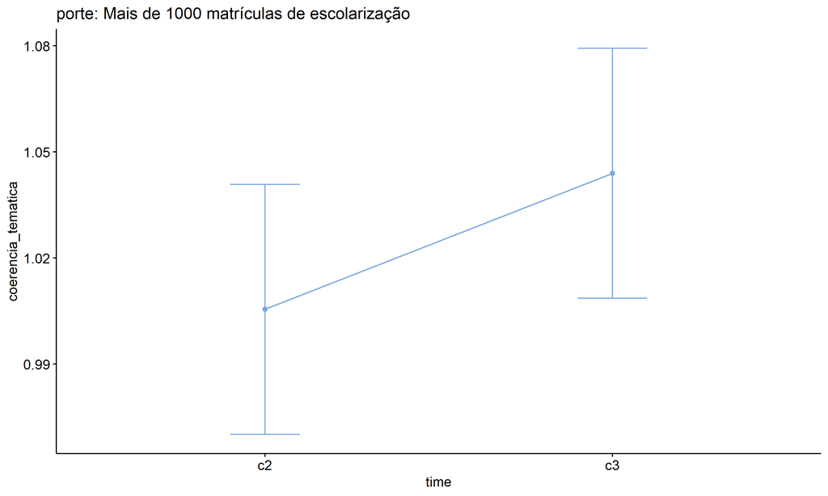

```r
emms.gg <- emms[which(emms$porte == "Mais de 1000 matrículas de escolarização"),]
if (nrow(emms.gg) > 0)
  ggline(emms.gg, x = "time", y = "emmean", color = "#7AA6DCFF", ylab = "coerencia_tematica") +
    geom_errorbar(aes(ymin = conf.low, ymax = conf.high),
                  width = 0.2, color = "#7AA6DCFF") +
    stat_pvalue_manual(
      add_xy_position(pwc[which(pwc$porte == "Mais de 1000 matrículas de escolarização"),],
                      x = "time", fun = "mean_se"),
      hide.ns = T, color = "#7AA6DCFF", tip.length = F) +
    labs(title = "porte: Mais de 1000 matrículas de escolarização")+
    theme(legend.text = element_blank())
```

## PairWise Computation after removing non.normal data

```r
if (length(non.ids) > 0)
  (pwc2 <- ldat2 %>% group_by(time) %>%
     emmeans_test(coerencia_tematica ~ porte, detailed = T, p.adjust.method = "bonferroni"))
```

```r
if (length(non.ids) > 0)
  (emms2 <- get_emmeans(pwc2))
```

```r
if (length(non.ids) > 0) {
  pwc2 <- add_xy_position(pwc2, x = "time", fun = "mean_se", dodge = 0.25)
  pd2 <- position_dodge(width = 0.25)

  ggline(emms2, x = "time", y = "emmean", color = "porte",
         palette = c("#0073C2FF","#EFC000FF","#868686FF","#CD534CFF","#7AA6DCFF"),
         position = pd, ylab = "coerencia_tematica") +
    geom_errorbar(aes(ymin = conf.low, ymax = conf.high, color = porte),
                position = pd, width = 0.2) +
    stat_pvalue_manual(pwc2, hide.ns = T, tip.length = F, linetype = 1)
}
```

```r
if (length(non.ids) > 0)
  (pwc2 <- ldat2 %>% group_by(porte) %>%
     emmeans_test(coerencia_tematica ~ time, detailed = T, p.adjust.method = "bonferroni"))
```

```r
if (length(non.ids) > 0)
  (emms2 <- get_emmeans(pwc2))
```

```r
if (length(non.ids) > 0) {
  emms.gg <- emms2[which(emms2$porte == "Até 50 matrículas de escolarização"),]
  if (nrow(emms.gg) > 0)
    ggline(emms.gg, x = "time", y = "emmean", color = "#0073C2FF", ylab = "coerencia_tematica") +
    geom_errorbar(aes(ymin = conf.low, ymax = conf.high),
                  width = 0.2, color = "#0073C2FF") +
    stat_pvalue_manual(
      add_xy_position(pwc[which(pwc$porte == "Até 50 matrículas de escolarização"),],
                      x = "time", fun = "mean_se"),
      hide.ns = T, color = "#0073C2FF", tip.length = F) +
    labs(title = "porte: Até 50 matrículas de escolarização") +
    theme(legend.text = element_blank())
}
```

```r
if (length(non.ids) > 0) {
  emms.gg <- emms2[which(emms2$porte == "Entre 201 e 500 matrículas de escolarização"),]
  if (nrow(emms.gg) > 0)
    ggline(emms.gg, x = "time", y = "emmean", color = "#EFC000FF", ylab = "coerencia_tematica") +
    geom_errorbar(aes(ymin = conf.low, ymax = conf.high),
                  width = 0.2, color = "#EFC000FF") +
    stat_pvalue_manual(
      add_xy_position(pwc[which(pwc$porte == "Entre 201 e 500 matrículas de escolarização"),],
                      x = "time", fun = "mean_se"),
      hide.ns = T, color = "#EFC000FF", tip.length = F) +
    labs(title = "porte: Entre 201 e 500 matrículas de escolarização") +
    theme(legend.text = element_blank())
}
```

```r
if (length(non.ids) > 0) {
  emms.gg <- emms2[which(emms2$porte == "Entre 501 e 1000 matrículas de escolarização"),]
  if (nrow(emms.gg) > 0)
    ggline(emms.gg, x = "time", y = "emmean", color = "#868686FF", ylab = "coerencia_tematica") +
    geom_errorbar(aes(ymin = conf.low, ymax = conf.high),
                  width = 0.2, color = "#868686FF") +
    stat_pvalue_manual(
      add_xy_position(pwc[which(pwc$porte == "Entre 501 e 1000 matrículas de escolarização"),],
                      x = "time", fun = "mean_se"),
      hide.ns = T, color = "#868686FF", tip.length = F) +
    labs(title = "porte: Entre 501 e 1000 matrículas de escolarização") +
    theme(legend.text = element_blank())
}
```

```r
if (length(non.ids) > 0) {
  emms.gg <- emms2[which(emms2$porte == "Entre 51 e 200 matrículas de escolarização"),]
  if (nrow(emms.gg) > 0)
    ggline(emms.gg, x = "time", y = "emmean", color = "#CD534CFF", ylab = "coerencia_tematica") +
    geom_errorbar(aes(ymin = conf.low, ymax = conf.high),
                  width = 0.2, color = "#CD534CFF") +
    stat_pvalue_manual(
      add_xy_position(pwc[which(pwc$porte == "Entre 51 e 200 matrículas de escolarização"),],
                      x = "time", fun = "mean_se"),
      hide.ns = T, color = "#CD534CFF", tip.length = F) +
    labs(title = "porte: Entre 51 e 200 matrículas de escolarização") +
    theme(legend.text = element_blank())
}
```

```r
if (length(non.ids) > 0) {
  emms.gg <- emms2[which(emms2$porte == "Mais de 1000 matrículas de escolarização"),]
  if (nrow(emms.gg) > 0)
    ggline(emms.gg, x = "time", y = "emmean", color = "#7AA6DCFF", ylab = "coerencia_tematica") +
    geom_errorbar(aes(ymin = conf.low, ymax = conf.high),
                  width = 0.2, color = "#7AA6DCFF") +
    stat_pvalue_manual(
      add_xy_position(pwc[which(pwc$porte == "Mais de 1000 matrículas de escolarização"),],
                      x = "time", fun = "mean_se"),
      hide.ns = T, color = "#7AA6DCFF", tip.length = F) +
    labs(title = "porte: Mais de 1000 matrículas de escolarização") +
    theme(legend.text = element_blank())
}
```